# Reproducible Analyses

#### Visualizations

Cleveland dot plot of Honor/Face/Dignity norms by country (non-centered)

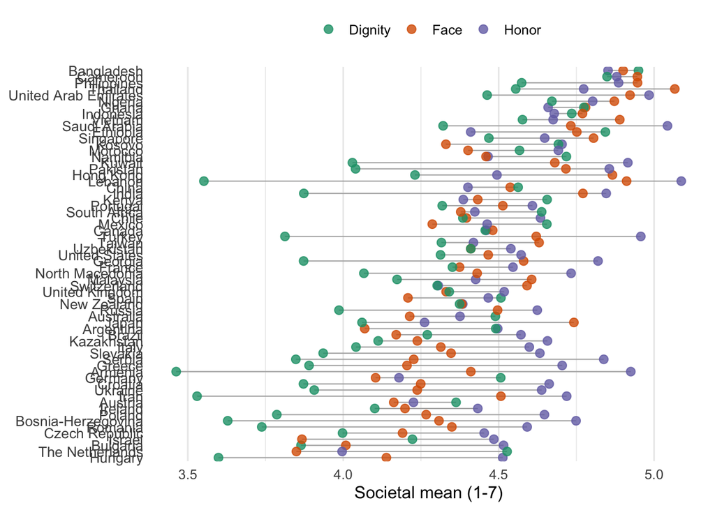

```r
# 1) Reshape to long format (one row per country × dimension)
df_long <- country_norm %>%
  select(
    country_res_full,
    Honor   = H_norm_mean_country,
    Face    = F_norm_mean_country,
    Dignity = D_norm_mean_country
  ) %>%
  pivot_longer(Honor:Dignity, names_to = "Dimension", values_to = "Score")

# 2) Choose how to order countries on the y-axis
#    Option A: by overall mean across the 3 dimensions (lowest → highest)
country_order <- df_long %>%
  group_by(country_res_full) %>%
  summarise(mean_score = mean(Score, na.rm = TRUE), .groups = "drop") %>%
  arrange(mean_score) %>%
  pull(country_res_full)

#    (Alternative)
#    # Option B: by Honor only
#    country_order <- df_long %>% filter(Dimension == "Honor") %>%
#      arrange(Score) %>% pull(country_res_full)
#
#    # Option C: alphabetical
#    country_order <- sort(unique(df_long$country_res_full))

# 3) Apply the order so ggplot respects it
df_long$country_res_full <- factor(df_long$country_res_full, levels = country_order)

# 4) Precompute per-country ranges (min→max across the three dimensions)
ranges <- df_long %>%
  group_by(country_res_full) %>%
  summarise(
    xmin = min(Score, na.rm = TRUE),
    xmax = max(Score, na.rm = TRUE),
    .groups = "drop"
  )

# 5) Plot
p <- ggplot() +
  # grey range bars (min→max per country)
  geom_segment(
    data = ranges,
    aes(x = xmin, xend = xmax, y = country_res_full, yend = country_res_full),
    color = "grey70",
    linewidth = 0.4
  ) +
  # colored points for the three dimensions
  geom_point(
    data = df_long,
    aes(x = Score, y = country_res_full, color = Dimension),
    size = 2.5, alpha = 0.8,
    # Use small vertical jitter if overlapping points are an issue; keep width at 0 for x
    position = position_jitter(height = 0, width = 0)
    # If you prefer perfectly aligned dots, use: position = position_identity()
  ) +
  # Color palette: Dark2 is colorblind-friendly; remove legend title
  scale_color_brewer(palette = "Dark2", name = NULL) +
  labs(x = "Societal mean (1-7)", y = NULL, title = NULL) +
  # Minimal theme + enforce true white background
  theme_minimal(base_size = 12) +
  theme(
    panel.background    = element_rect(fill = "white", color = NA),
    plot.background     = element_rect(fill = "white", color = NA),
    panel.grid.major.y  = element_blank(),     # cleaner y axis
    axis.text.y         = element_text(size = 10),
    legend.position     = "top"
  )

p
```

```r
# 6) Save
#    Adjust height if you have many countries (more rows → more height).
ggsave(
  filename = "figures/DHF_Norms_dotplot_noncentered.png",
  plot = p,
  width = 9, height = 14, dpi = 600
)

# Vector version for journals (crisp text/lines):
ggsave(
  filename = "figures/DHF_Norms_dotplot_noncentered.pdf",
  plot = p,
  width = 9, height = 14
)
```

Cleveland dot plot of Honor/Face/Dignity norms by country (non-centered & centered)

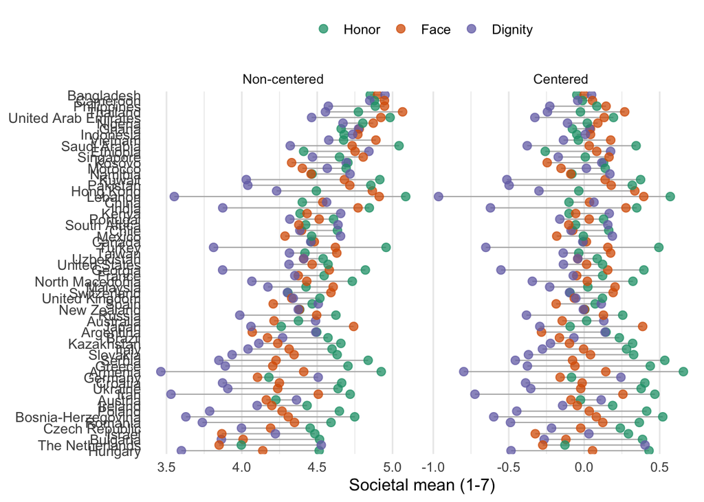

```r
# 1) Long data for NON-centered
df_nc <- country_norm %>%
  select(
    country_res_full,
    Honor   = H_norm_mean_country,
    Face    = F_norm_mean_country,
    Dignity = D_norm_mean_country
  ) %>%
  pivot_longer(Honor:Dignity, names_to = "Dimension", values_to = "Score") %>%
  mutate(Centering = "Non-centered")

# 2) Long data for CENTERED (same dimension names)
df_c <- country_norm %>%
  select(
    country_res_full,
    Honor   = H_normc_mean_country,
    Face    = F_normc_mean_country,
    Dignity = D_normc_mean_country
  ) %>%
  pivot_longer(Honor:Dignity, names_to = "Dimension", values_to = "Score") %>%
  mutate(Centering = "Centered")

# 3) Combine + set factor orders
df_both <- bind_rows(df_nc, df_c) %>%
  mutate(
    Dimension = factor(Dimension, levels = c("Honor","Face","Dignity")),
    Centering = factor(Centering, levels = c("Non-centered","Centered"))
  )

# 4) Fix a single country order (so both facets share the same y-axis)
#    Here: order by the NON-centered average across the 3 dimensions (intuitive baseline)
country_order <- df_nc %>%
  group_by(country_res_full) %>%
  summarise(mean_score = mean(Score, na.rm = TRUE), .groups = "drop") %>%
  arrange(mean_score) %>%
  pull(country_res_full)

df_both$country_res_full <- factor(df_both$country_res_full, levels = country_order)

# 5) (Optional) draw per-country range segments across the 3 dimensions *within each facet*
ranges <- df_both %>%
  group_by(Centering, country_res_full) %>%
  summarise(
    xmin = min(Score, na.rm = TRUE),
    xmax = max(Score, na.rm = TRUE),
    .groups = "drop"
  )

# 6) Plot: one panel per Centering; dots colored by Dimension
set.seed(123)  # reproducible jitter

p <- ggplot() +
  # grey connector showing spread across the three dimensions for each country in each facet
  geom_segment(
    data = ranges,
    aes(x = xmin, xend = xmax, y = country_res_full, yend = country_res_full),
    color = "grey70", linewidth = 0.4
  ) +
  # three dots per country (Honor/Face/Dignity)
  geom_point(
    data = df_both,
    aes(x = Score, y = country_res_full, color = Dimension),
    size = 2.5, alpha = 0.75,
    position = position_jitter(height = 0, width = 0)  # small vertical separation
  ) +
  facet_wrap(~ Centering, nrow = 1, scales = "free_x") +  # free_x lets centered vs non-centered have their own scales
  scale_color_brewer(palette = "Dark2", name = NULL) +
  labs(x = "Societal mean (1-7)", y = NULL, title = NULL) +
  theme_minimal(base_size = 12) +
  theme(
    panel.background   = element_rect(fill = "white", color = NA),
    plot.background    = element_rect(fill = "white", color = NA),
    panel.grid.major.y = element_blank(),
    axis.text.y        = element_text(size = 10),
    legend.position    = "top"
  )

p
```

```r
# 7) Save (increase height for many countries)
ggsave("figures/DHF_Norms_dotplot.png", p,
       width = 18, height = 14, dpi = 600)
ggsave("figures/DHF_Norms_dotplot.pdf", p,
       width = 18, height = 14)
```

World map of Honor/Face/Dignity norms (non-centered scores)

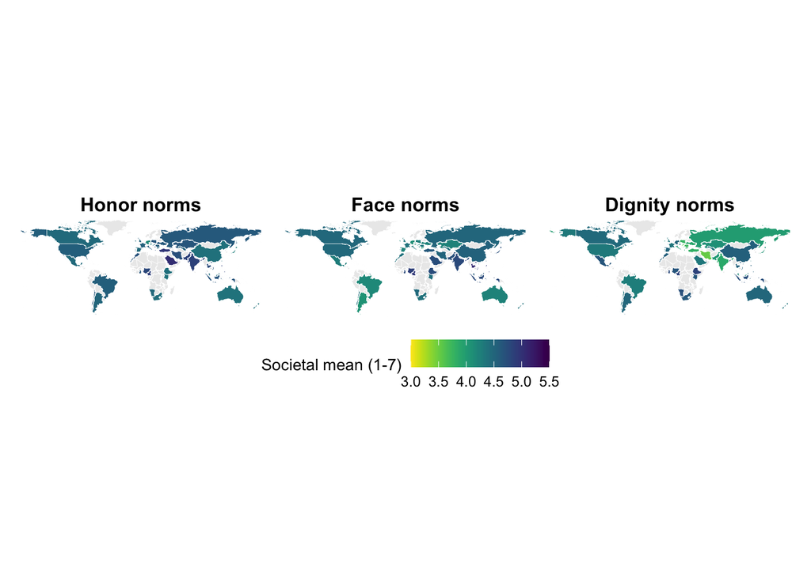

```r
# --- 1) World polygons (drop Antarctica for cleaner view) ---
# Uses Natural Earth country names for joining. Currently in geographic (WGS84) CRS.
# If you want Robinson, add: world <- st_transform(world, "+proj=robin") after this block.
world <- ne_countries(scale = "medium", returnclass = "sf") |>
  select(name, geometry) |>
  filter(name != "Antarctica")

# --- 2) Rename and recode to EXACT Natural Earth names ---
# Harmonize your dataset's country labels to match Natural Earth.
# Add more entries to recode() as mismatches arise.
country_data <- country_norm |>
  transmute(
    name    = country_res_full,
    Honor   = H_norm_mean_country,
    Face    = F_norm_mean_country,
    Dignity = D_norm_mean_country
  ) |>
  mutate(
    name = dplyr::recode(
      name,
      "Bosnia-Herzegovina" = "Bosnia and Herzegovina",
      "Czech Republic"     = "Czechia",
      "The Netherlands"    = "Netherlands",
      "United States"      = "United States of America"
    )
  )

# --- 3) Join to polygons ---
# Left join keeps all polygons; countries without data will map as NA (filled by na.value).
world_join <- world |> left_join(country_data, by = "name")

# (Optional) quickly see if any still unmatched
# Use this to catch remaining naming issues and extend recode() above.
# anti_join(country_data, st_drop_geometry(world), by = "name") |> distinct(name)

# --- 4) Long form + consistent limits across facets (so colors are comparable) ---
# Non-centered scores: keep a single limit across all three to make colors comparable row-wise.
world_long <- world_join |>
  select(geometry, Honor, Face, Dignity) |>
  pivot_longer(c(Honor, Face, Dignity),
               names_to = "Dimension", values_to = "Score") |>
  mutate(Dimension = factor(Dimension, levels = c("Honor","Face","Dignity")))

# Set limits explicitly for reproducibility; alternatively use range(world_long$Score, na.rm=TRUE).
lims <- c(3,5.5) # range(world_long$Score, na.rm = TRUE)

# --- 5) Plot: titles centered, thin white borders, compact legend ---
# Apply the same basic theme to all six maps; legends will later be collected per row.
common_theme <- theme(
  plot.title = element_text(hjust = 0.5, size = 12, face = "bold"),
  legend.position = "bottom",
  legend.title = element_text(size = 10),
  legend.text  = element_text(size = 9)
)

# Non-centered maps (viridis option "C")
p_honor <- ggplot(filter(world_long, Dimension == "Honor")) +
  geom_sf(aes(fill = Score), color = "white", size = 0.1) +
  scale_fill_viridis(name = "Societal mean (1-7)", option = "D",
                     limits = lims, na.value = "grey92", direction = -1) +
  labs(title = "Honor norms") +
  theme_void() +
  common_theme

p_face <- ggplot(filter(world_long, Dimension == "Face")) +
  geom_sf(aes(fill = Score), color = "white", size = 0.1) +
  scale_fill_viridis(name = "Societal mean (1-7)", option = "D",
                     limits = lims, na.value = "grey92", direction = -1) +
  labs(title = "Face norms") +
  theme_void() +
  common_theme

p_dignity <- ggplot(filter(world_long, Dimension == "Dignity")) +
  geom_sf(aes(fill = Score), color = "white", size = 0.1) +
  scale_fill_viridis(name = "Societal mean (1-7)", option = "D",
                     limits = lims, na.value = "grey92", direction = -1) +
  labs(title = "Dignity norms") +
  theme_void() +
  common_theme

# ---- build plot for non-centered scores only ----
p <- (p_honor | p_face | p_dignity) +
  plot_layout(guides = "collect") &
  theme(
    legend.position  = "bottom"
  )
p
```

```r
# Export plot
ggsave("figures/DHF_Norms_worldmap_noncentered.png", p,
       width = 18, height = 4, dpi = 600)
ggsave("figures/DHF_Norms_worldmap_noncentered.pdf", p,
       width = 18, height = 4)
```

World map of Honor/Face/Dignity norms

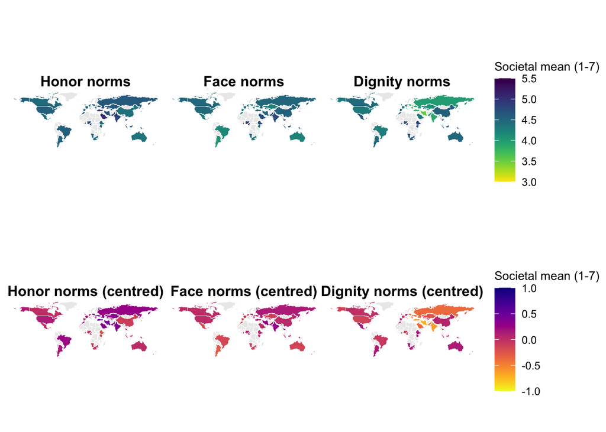

```r
# --- 1) World polygons (drop Antarctica for cleaner view) ---
# Uses Natural Earth country names for joining. Currently in geographic (WGS84) CRS.
# If you want Robinson, add: world <- st_transform(world, "+proj=robin") after this block.
world <- ne_countries(scale = "medium", returnclass = "sf") |>
  select(name, geometry) |>
  filter(name != "Antarctica")

# --- 2) Rename and recode to EXACT Natural Earth names ---
# Harmonize your dataset's country labels to match Natural Earth.
# Add more entries to recode() as mismatches arise.
country_data <- country_norm |>
  transmute(
    name    = country_res_full,
    Honor   = H_norm_mean_country,
    Face    = F_norm_mean_country,
    Dignity = D_norm_mean_country,
    HonorC   = H_normc_mean_country,
    FaceC    = F_normc_mean_country,
    DignityC = D_normc_mean_country,
  ) |>
  mutate(
    name = dplyr::recode(
      name,
      "Bosnia-Herzegovina" = "Bosnia and Herzegovina",
      "Czech Republic"     = "Czechia",
      "The Netherlands"    = "Netherlands",
      "United States"      = "United States of America"
    )
  )

# --- 3) Join to polygons ---
# Left join keeps all polygons; countries without data will map as NA (filled by na.value).
world_join <- world |> left_join(country_data, by = "name")

# (Optional) quickly see if any still unmatched
# Use this to catch remaining naming issues and extend recode() above.
# anti_join(country_data, st_drop_geometry(world), by = "name") |> distinct(name)

# --- 4) Long form + consistent limits across facets (so colors are comparable) ---
# Non-centered scores: keep a single limit across all three to make colors comparable row-wise.
world_long <- world_join |>
  select(geometry, Honor, Face, Dignity) |>
  pivot_longer(c(Honor, Face, Dignity),
               names_to = "Dimension", values_to = "Score") |>
  mutate(Dimension = factor(Dimension, levels = c("Honor","Face","Dignity")))

# Set limits explicitly for reproducibility; alternatively use range(world_long$Score, na.rm=TRUE).
lims <- c(3,5.5) # range(world_long$Score, na.rm = TRUE)

# Centered scores: keep them separate (different palette/legend) and use symmetric limits if possible.
world_long_centered <- world_join |>
  select(geometry, HonorC, FaceC, DignityC) |>
  pivot_longer(c(HonorC, FaceC, DignityC),
               names_to = "Dimension", values_to = "Score") |>
  mutate(Dimension = factor(Dimension, levels = c("HonorC","FaceC","DignityC")))

# Prefer symmetric bounds around 0 for interpretability (edit as needed).
limsc <- c(-1,1) # range(world_long_centered$Score, na.rm = TRUE)

# --- 5) Plot: titles centered, thin white borders, compact legend ---
# Apply the same basic theme to all six maps; legends will later be collected per row.
common_theme <- theme(
  plot.title = element_text(hjust = 0.5, size = 12, face = "bold"),
  legend.position = "bottom",
  legend.title = element_text(size = 10),
  legend.text  = element_text(size = 9)
)

# Non-centered maps (viridis option "C")
p_honor <- ggplot(filter(world_long, Dimension == "Honor")) +
  geom_sf(aes(fill = Score), color = "white", size = 0.1) +
  scale_fill_viridis(name = "Societal mean (1-7)", option = "D",
                     limits = lims, na.value = "grey92", direction = -1) +
  labs(title = "Honor norms") +
  theme_void() +
  common_theme

p_face <- ggplot(filter(world_long, Dimension == "Face")) +
  geom_sf(aes(fill = Score), color = "white", size = 0.1) +
  scale_fill_viridis(name = "Societal mean (1-7)", option = "D",
                     limits = lims, na.value = "grey92", direction = -1) +
  labs(title = "Face norms") +
  theme_void() +
  common_theme

p_dignity <- ggplot(filter(world_long, Dimension == "Dignity")) +
  geom_sf(aes(fill = Score), color = "white", size = 0.1) +
  scale_fill_viridis(name = "Societal mean (1-7)", option = "D",
                     limits = lims, na.value = "grey92", direction = -1) +
  labs(title = "Dignity norms") +
  theme_void() +
  common_theme

# Centered maps (viridis option "D" to visually differentiate from non-centered)
p_honorc <- ggplot(filter(world_long_centered, Dimension == "HonorC")) +
  geom_sf(aes(fill = Score), color = "white", size = 0.1) +
  scale_fill_viridis(name = "Societal mean (1-7)", option = "C",
                     limits = limsc, na.value = "grey92", direction = -1) +
  labs(title = "Honor norms (centred)") +
  theme_void() +
  common_theme

p_facec <- ggplot(filter(world_long_centered, Dimension == "FaceC")) +
  geom_sf(aes(fill = Score), color = "white", size = 0.1) +
  scale_fill_viridis(name = "Societal mean (1-7)", option = "C",
                     limits = limsc, na.value = "grey92", direction = -1) +
  labs(title = "Face norms (centred)") +
  theme_void() +
  common_theme

p_dignityc <- ggplot(filter(world_long_centered, Dimension == "DignityC")) +
  geom_sf(aes(fill = Score), color = "white", size = 0.1) +
  scale_fill_viridis(name = "Societal mean (1-7)", option = "C",
                     limits = limsc, na.value = "grey92", direction = -1) +
  labs(title = "Dignity norms (centred)") +
  theme_void() +
  common_theme

# ---- build two separate rows (each with its own collected legend) ----
# Keep guide collection INSIDE each row so the top row (C) and bottom row (D)
# retain different palettes and their own legends.
row_nc <- (p_honor | p_face | p_dignity) +
  plot_layout(guides = "collect") &
  theme(
    legend.position = "right",          # put legend to the side of the row
    legend.direction = "vertical"       # vertical legend for compact height
  )

row_c <- (p_honorc | p_facec | p_dignityc) +
  plot_layout(guides = "collect") &
  theme(
    legend.position = "right",
    legend.direction = "vertical"
  )

# Final assembly: stack the two rows. Each keeps its own legend and color scale.
final_plot <- row_nc / row_c
final_plot
```

```r
# Export plot
ggsave("figures/DHF_Norms_worldmap.png", final_plot,
       width = 18, height = 6, dpi = 600)
ggsave("figures/DHF_Norms_worldmap.pdf", final_plot,
       width = 18, height = 6)
```

### Main study: Country-level correlates of DHF

Ecological antecedents of DHF endorsement and norms

```r
apaTables::apa.cor.table(
  dt4 %>%
    select(D_normc_mean_country, H_normc_mean_country,
           F_normc_mean_country, D_endc_mean_country,
           H_endc_mean_country, F_endc_mean_country,
           wb_pop_density_1961, ms_pathogen_9items,
           icb_crisis_participations, icb_avg_violence_level,
           wb_gdp_pcap_usd_1960, fiw_F_2013,
           fiw_C_2013, fiw_Total_2013
           )
)
```

```
##
##
## Means, standard deviations, and correlations with confidence intervals
##
##
##   Variable                     M      SD     1            2
##   1. D_normc_mean_country      -0.19  0.29
##
##   2. H_normc_mean_country      0.17   0.22   -.88**
##                                              [-.89, -.88]
##
##   3. F_normc_mean_country      0.02   0.14   -.68**       .25**
##                                              [-.68, -.67] [.24, .26]
##
##   4. D_endc_mean_country       0.67   0.26   -.00         .25**
##                                              [-.02, .01]  [.24, .26]
##
##   5. H_endc_mean_country       -0.28  0.14   -.50**       .47**
##                                              [-.51, -.49] [.46, .48]
##
##   6. F_endc_mean_country       -0.38  0.22   .32**        -.60**
##                                              [.31, .34]   [-.61, -.60]
##
##   7. wb_pop_density_1961       115.71 364.37 -.04**       -.09**
##                                              [-.06, -.03] [-.10, -.07]
##
##   8. ms_pathogen_9items        -0.04  0.63   .07**        -.19**
##                                              [.05, .08]   [-.21, -.18]
##
##   9. icb_crisis_participations 19.74  21.28  -.15**       .16**
##                                              [-.16, -.13] [.14, .17]
##
##   10. icb_avg_violence_level   2.06   0.50   .14**        -.14**
##                                              [.12, .15]   [-.16, -.13]
##
##   11. wb_gdp_pcap_usd_1960     848.46 928.38 .24**        -.12**
##                                              [.23, .25]   [-.13, -.11]
##
##   12. fiw_F_2013               9.71   4.11   .25**        -.10**
##                                              [.24, .26]   [-.12, -.09]
```

[output cut: 83 more lines]

```
##   [.24, .26]  [.04, .07]   [.70, .71]
##
##   .17**       -.02**       .65**      .93**
##   [.15, .18]  [-.03, -.01] [.64, .66] [.92, .93]
##
##   .16**       -.04**       .65**      .94**      .95**
##   [.15, .18]  [-.06, -.03] [.65, .66] [.94, .94] [.95, .95]
##
##
## Note. M and SD are used to represent mean and standard deviation, respectively.
## Values in square brackets indicate the 95% confidence interval.
## The confidence interval is a plausible range of population correlations
## that could have caused the sample correlation (Cumming, 2014).
##  * indicates p < .05. ** indicates p < .01.
##
```

DHF and current country performance

```r
apaTables::apa.cor.table(
  dt4 %>%
    select(D_normc_mean_country, H_normc_mean_country,
           F_normc_mean_country, D_endc_mean_country,
           H_endc_mean_country, F_endc_mean_country,
           wb_gdp_pcap_usd_most_recent, gii_value_2021,
           wb_gini_2020, fiw_Total_2023, hdi_value_2021
           )
)
```

```
##
##
## Means, standard deviations, and correlations with confidence intervals
##
##
##   Variable                       M        SD       1            2
##   1. D_normc_mean_country        -0.19    0.29
##
##   2. H_normc_mean_country        0.17     0.22     -.88**
##                                                    [-.89, -.88]
##
##   3. F_normc_mean_country        0.02     0.14     -.68**       .25**
##                                                    [-.68, -.67] [.24, .26]
##
##   4. D_endc_mean_country         0.67     0.26     -.00         .25**
##                                                    [-.02, .01]  [.24, .26]
##
##   5. H_endc_mean_country         -0.28    0.14     -.50**       .47**
##                                                    [-.51, -.49] [.46, .48]
##
##   6. F_endc_mean_country         -0.38    0.22     .32**        -.60**
##                                                    [.31, .34]   [-.61, -.60]
##
##   7. wb_gdp_pcap_usd_most_recent 23788.84 24005.31 .23**        -.17**
##                                                    [.22, .24]   [-.18, -.16]
##
##   8. gii_value_2021              0.25     0.17     .06**        -.22**
##                                                    [.05, .08]   [-.23, -.20]
##
##   9. wb_gini_2020                35.03    5.10     .42**        -.39**
##                                                    [.41, .44]   [-.41, -.38]
##
##   10. fiw_Total_2023             65.95    25.49    .36**        -.19**
##                                                    [.35, .37]   [-.20, -.18]
##
##   11. hdi_value_2021             0.80     0.12     -.11**       .22**
##                                                    [-.12, -.10] [.21, .23]
##
##   3            4            5            6            7            8
##
```

[output cut: 56 more lines]

```
##
##
##   -.01
##   [-.02, .01]
##
##   -.08**       .50**
##   [-.10, -.07] [.50, .51]
##
##
## Note. M and SD are used to represent mean and standard deviation, respectively.
## Values in square brackets indicate the 95% confidence interval.
## The confidence interval is a plausible range of population correlations
## that could have caused the sample correlation (Cumming, 2014).
##  * indicates p < .05. ** indicates p < .01.
##
```

DHF and other cultural dimensions

ASK LUCY ABOUT THIS SECTION - A few missing variables - The Openness_to_Change_mean_country, Conservation_mean_country, Self_Enhancement_mean_country … no code found on how these were calculated - Also need to figure out where the other variables are

```r
# believe these are mean_country centered above, but should check
apaTables::apa.cor.table(
  dt4 %>%
    select(D_normc_mean_country, H_normc_mean_country,
           F_normc_mean_country, D_endc_mean_country,
           H_endc_mean_country, F_endc_mean_country,
           # Openness_to_Change_mean_country,
           Openness_to_Change,
           # Conservation_mean_country,
           Conservation,
           # Self_Transcendence_mean_country,
           Self_Transcendence,
           # Self_Enhancement_mean_country,
           Self_Enhancement,
           tl_tightness, mk_individualism_collectivism,
           mk_flexibility_monumentalism, rm_relational_mobility
           # `o-c`, `st-se`
           # not sure what these are need to update var names
           )
)
```

```
##
##
## Means, standard deviations, and correlations with confidence intervals
##
##
##   Variable                          M      SD    1            2
##   1. D_normc_mean_country           -0.19  0.29
##
##   2. H_normc_mean_country           0.17   0.22  -.88**
##                                                  [-.89, -.88]
##
##   3. F_normc_mean_country           0.02   0.14  -.68**       .25**
##                                                  [-.68, -.67] [.24, .26]
##
##   4. D_endc_mean_country            0.67   0.26  -.00         .25**
##                                                  [-.02, .01]  [.24, .26]
##
##   5. H_endc_mean_country            -0.28  0.14  -.50**       .47**
##                                                  [-.51, -.49] [.46, .48]
##
##   6. F_endc_mean_country            -0.38  0.22  .32**        -.60**
##                                                  [.31, .34]   [-.61, -.60]
##
##   7. Openness_to_Change             4.39   0.87  -.01         -.03**
##                                                  [-.02, .00]  [-.04, -.01]
##
##   8. Conservation                   4.11   0.88  .00          -.08**
##                                                  [-.01, .02]  [-.09, -.07]
##
##   9. Self_Transcendence             4.88   0.77  .04**        .01
##                                                  [.03, .05]   [-.01, .02]
##
##   10. Self_Enhancement              4.04   1.05  -.03**       -.04**
##                                                  [-.05, -.02] [-.05, -.02]
##
##   11. tl_tightness                  1.96   0.26  -.04**       -.23**
##                                                  [-.05, -.02] [-.25, -.22]
##
##   12. mk_individualism_collectivism -32.57 89.86 .07**        .09**
##                                                  [.06, .08]   [.08, .10]
```

[output cut: 83 more lines]

```
##   [-.01, .02]  [-.16, -.13] [-.63, -.61]
##
##   -.12**       -.04**       -.29**       .65**
##   [-.13, -.11] [-.05, -.03] [-.30, -.28] [.64, .65]
##
##   .17**        -.02*        -.34**       .30**      -.30**
##   [.16, .19]   [-.04, -.00] [-.36, -.33] [.28, .32] [-.32, -.28]
##
##
## Note. M and SD are used to represent mean and standard deviation, respectively.
## Values in square brackets indicate the 95% confidence interval.
## The confidence interval is a plausible range of population correlations
## that could have caused the sample correlation (Cumming, 2014).
##  * indicates p < .05. ** indicates p < .01.
##
```

### Main study: Individual-level correlates of DHF

#### DHF and prosociality

[Tables in line with prereg H2-H3]

```r
# ============================================================================
# H2 ANALYSIS USING dt5 (PROSOCIAL OUTCOME)
# ============================================================================

# reset dt5 so that we have all the variables
dt5 <- subset(dt4, dictator_cpass==1)
dt5$prosocial <- as.numeric(dt5$Dictator_decision)

print("Preparing H2 analysis with misty centering")
```

```
## [1] "Preparing H2 analysis with misty centering"
```

```r
print(paste("Dataset has", nrow(dt5), "participants"))
```

```
## [1] "Dataset has 21544 participants"
```

```r
# Proper multilevel centering using misty package
DF_H2 <- dt5 %>%
  mutate(
    # Group-mean centering for individual-level variables (Level 1)
    D_self_end_CWC = center(D_self_end, type = "CWC", cluster = country_res_full),
    D_other_end_CWC = center(D_other_end, type = "CWC", cluster = country_res_full),
    H_self_end_CWC = center(H_self_end, type = "CWC", cluster = country_res_full),
    H_other_end_CWC = center(H_other_end, type = "CWC", cluster = country_res_full),
    F_self_end_CWC = center(F_self_end, type = "CWC", cluster = country_res_full),
    F_other_end_CWC = center(F_other_end, type = "CWC", cluster = country_res_full)
  )

# Data quality check
print("Data quality check...")
```

```
## [1] "Data quality check..."
```

```r
analysis_vars <- c("prosocial", "D_self_end_CWC", "D_other_end_CWC",
                   "H_self_end_CWC", "H_other_end_CWC",
                   "F_self_end_CWC", "F_other_end_CWC", "country_res_full")

# Check which variables exist
available_vars <- analysis_vars[analysis_vars %in% names(DF_H2)]
print("Available analysis variables:")
```

```
## [1] "Available analysis variables:"
```

```r
print(available_vars)
```

```
## [1] "prosocial"        "D_self_end_CWC"   "D_other_end_CWC"  "H_self_end_CWC"
## [5] "H_other_end_CWC"  "F_self_end_CWC"   "F_other_end_CWC"  "country_res_full"
```

```r
# Complete cases
complete_cases <- sum(complete.cases(DF_H2[, available_vars]))
print(paste("Complete cases for analysis:", complete_cases, "out of", nrow(DF_H2)))
```

```
## [1] "Complete cases for analysis: 21539 out of 21544"
```

```r
# Country sample sizes
country_sizes <- DF_H2 %>%
  filter(!is.na(prosocial)) %>%
  group_by(country_res_full) %>%
  summarise(n = n()) %>%
  arrange(desc(n))

print("Sample sizes by country (top 10):")
```

```
## [1] "Sample sizes by country (top 10):"
```

```r
print(head(country_sizes, 10))
```

```
## # A tibble: 10 × 2
##    country_res_full     n
##    <fct>            <int>
##  1 Turkey            1772
##  2 United States     1426
##  3 Australia          847
##  4 Philippines        752
##  5 Germany            678
##  6 Canada             648
##  7 Croatia            637
##  8 Poland             635
##  9 Italy              544
## 10 United Kingdom     465
```

```r
print(paste("Number of countries:", nrow(country_sizes)))
```

```
## [1] "Number of countries: 63"
```

```r
print(paste("Minimum country sample size:", min(country_sizes$n)))
```

```
## [1] "Minimum country sample size: 49"
```

```r
# H2 Main Analysis - six factors model
print("\nRunning H2 Analysis - Six DHF Facets Model...")
```

```
## [1] "\nRunning H2 Analysis - Six DHF Facets Model..."
```

```r
h2.fit <- lmer(prosocial ~ D_self_end_CWC + D_other_end_CWC +
                 H_self_end_CWC + H_other_end_CWC +
                 F_self_end_CWC + F_other_end_CWC +
                 (1|country_res_full),
               data = DF_H2,
               REML = FALSE)

print("H2 MODEL RESULTS:")
```

```
## [1] "H2 MODEL RESULTS:"
```

```r
h2_params <- parameters(h2.fit, standardize = "refit", ci = 0.95)
print(h2_params)
```

```
## # Fixed Effects
##
## Parameter       | Coefficient |       SE |         95% CI | t(21530) |      p
## -----------------------------------------------------------------------------
## (Intercept)     |        0.02 |     0.02 | [-0.03,  0.06] |     0.63 | 0.528
## D self end CWC  |   -4.10e-03 | 7.56e-03 | [-0.02,  0.01] |    -0.54 | 0.587
## D other end CWC |        0.08 | 7.55e-03 | [ 0.07,  0.10] |    10.89 | < .001
## H self end CWC  |       -0.03 | 8.14e-03 | [-0.04, -0.01] |    -3.13 | 0.002
## H other end CWC |       -0.01 | 9.18e-03 | [-0.03,  0.01] |    -1.13 | 0.259
## F self end CWC  |       -0.03 | 9.07e-03 | [-0.04, -0.01] |    -2.81 | 0.005
## F other end CWC |        0.04 | 8.87e-03 | [ 0.03,  0.06] |     4.91 | < .001
##
## # Random Effects
##
## Parameter                        | Coefficient
## ----------------------------------------------
## SD (Intercept: country_res_full) |        0.18
## SD (Residual)                    |        0.98
```

```
##
## Uncertainty intervals (equal-tailed) and p-values (two-tailed) computed
##   using a Wald t-distribution approximation. Uncertainty intervals for
##   random effect variances computed using a Wald z-distribution
##   approximation.
```

```r
# Model performance
print("\nModel Performance:")
```

```
## [1] "\nModel Performance:"
```

```r
perf <- performance(h2.fit)
```

```
## Model was not fitted with REML, however, `estimator = "REML"`. Set
##   `estimator = "ML"` to obtain identical results as from `AIC()`.
```

```r
print(perf)
```

```
## # Indices of model performance
##
## AIC     |    AICc |     BIC | R2 (cond.) | R2 (marg.) |   ICC |  RMSE | Sigma
## -----------------------------------------------------------------------------
## 84768.8 | 84768.8 | 84840.6 |      0.040 |      0.008 | 0.032 | 1.721 | 1.723
```

```r
# R-squared values
r2_vals <- r2(h2.fit)
print(paste("Marginal R² (fixed effects):", round(r2_vals$R2_marginal, 3)))
```

```
## [1] "Marginal R² (fixed effects): 0.008"
```

```r
print(paste("Conditional R² (fixed + random):", round(r2_vals$R2_conditional, 3)))
```

```
## [1] "Conditional R² (fixed + random): 0.04"
```

```r
# Check column names and create standardized results table
print("\nColumn names in h2_params:")
```

```
## [1] "\nColumn names in h2_params:"
```

```r
print(names(h2_params))
```

```
##  [1] "Parameter"   "Coefficient" "SE"          "CI"          "CI_low"
##  [6] "CI_high"     "t"           "df_error"    "p"           "Effects"
## [11] "Group"
```

```r
# Create standardized results table with proper column references
print("\nStandardized Coefficients with 95% CI and p-values:")
```

```
## [1] "\nStandardized Coefficients with 95% CI and p-values:"
```

```r
h2_results <- data.frame(
  Parameter = h2_params$Parameter,
  Std_Beta = round(h2_params$Coefficient, 4),  # Using Coefficient instead of Std_Coefficient
  CI_Lower = round(h2_params$CI_low, 4),
  CI_Upper = round(h2_params$CI_high, 4),
  p_value = round(h2_params$p, 4),
  Significance = ifelse(h2_params$p < 0.001, "***",
                        ifelse(h2_params$p < 0.01, "**",
                               ifelse(h2_params$p < 0.05, "*", "")))
)
print(h2_results)
```

```
##           Parameter Std_Beta CI_Lower CI_Upper p_value Significance
## 1       (Intercept)   0.0152  -0.0322   0.0627  0.5285
## 2    D_self_end_CWC  -0.0041  -0.0189   0.0107  0.5875
## 3   D_other_end_CWC   0.0823   0.0675   0.0971  0.0000          ***
## 4    H_self_end_CWC  -0.0255  -0.0414  -0.0095  0.0018           **
## 5   H_other_end_CWC  -0.0104  -0.0284   0.0076  0.2585
## 6    F_self_end_CWC  -0.0254  -0.0432  -0.0077  0.0050           **
## 7   F_other_end_CWC   0.0435   0.0261   0.0609  0.0000          ***
## 8    SD (Intercept)   0.1797       NA       NA      NA         <NA>
## 9 SD (Observations)   0.9848       NA       NA      NA         <NA>
```

```r
# Random effects
rand_effects <- VarCorr(h2.fit)
print("\nRandom Effects Variance:")
```

```
## [1] "\nRandom Effects Variance:"
```

```r
print(rand_effects)
```

```
##  Groups           Name        Std.Dev.
##  country_res_full (Intercept) 0.31438
##  Residual                     1.72308
```

```r
# ============================================================================
# H3 ANALYSIS - MULTILEVEL PATH MODELS
# ===========================================================================

# STEP 1: Prepare prosocial data (dt5) with proper misty centering
print("Preparing prosocial model data from dt5...")
```

```
## [1] "Preparing prosocial model data from dt5..."
```

```r
DF_prosocial_H3 <- dt5 %>%
  filter(!is.na(prosocial) & !is.na(D_end) & !is.na(H_end) & !is.na(F_end) &
           !is.na(D_norm_mean_country) & !is.na(H_norm_mean_country) & !is.na(F_norm_mean_country)) %>%
  mutate(
    # Individual-level variables: group-mean centering (CWC)
    D_end_CWC = center(D_end, type = "CWC", cluster = country_res_full),
    H_end_CWC = center(H_end, type = "CWC", cluster = country_res_full),
    F_end_CWC = center(F_end, type = "CWC", cluster = country_res_full),

    # Country-level variables: grand-mean centering (CGM)
    D_norm_agg_CGM = center(D_norm_mean_country, type = "CGM"),
    H_norm_agg_CGM = center(H_norm_mean_country, type = "CGM"),
    F_norm_agg_CGM = center(F_norm_mean_country, type = "CGM")
  )

print(paste("Prosocial model sample size:", nrow(DF_prosocial_H3)))
```

```
## [1] "Prosocial model sample size: 21539"
```

```r
# STEP 2: Prepare reciprocity data (dt6) with proper misty centering
# reset dt6 since it doesn't have these variables
dt6 <- subset(dt4, ultimatum_cpass==1) #N=20626

# Merge with dt6
dt6 <- merge(dt6, neg_rec_df, by="ResponseId")
dt6$UG_negrec <- as.numeric(dt6$UG_negrec)
dt6 <- merge(dt6, pos_rec_df, by="ResponseId")

print("Preparing reciprocity model data from dt6...")
```

```
## [1] "Preparing reciprocity model data from dt6..."
```

```r
DF_reciprocity_H3 <- dt6 %>%
  filter(!is.na(UG_posrec) & !is.na(UG_negrec) &
           !is.na(D_end) & !is.na(H_end) & !is.na(F_end) &
           !is.na(D_norm_mean_country) & !is.na(H_norm_mean_country) & !is.na(F_norm_mean_country)) %>%
  mutate(
    # Individual-level variables: group-mean centering (CWC)
    D_end_CWC = center(D_end, type = "CWC", cluster = country_res_full),
    H_end_CWC = center(H_end, type = "CWC", cluster = country_res_full),
    F_end_CWC = center(F_end, type = "CWC", cluster = country_res_full),

    # Country-level variables: grand-mean centering (CGM)
    D_norm_agg_CGM = center(D_norm_mean_country, type = "CGM"),
    H_norm_agg_CGM = center(H_norm_mean_country, type = "CGM"),
    F_norm_agg_CGM = center(F_norm_mean_country, type = "CGM")
  )

print(paste("Reciprocity model sample size:", nrow(DF_reciprocity_H3)))
```

```
## [1] "Reciprocity model sample size: 20516"
```

```r
# STEP 3: H3 Model 1 - Prosocial Behavior
print("\nRunning H3 Model 1: Prosocial Behavior...")
```

```
## [1] "\nRunning H3 Model 1: Prosocial Behavior..."
```

```r
prosocial.model <- '
# Level 1: Individual endorsement predicting prosocial behavior
prosocial ~ D_end_CWC + H_end_CWC + F_end_CWC

# Level 2: Country-level norms predicting prosocial behavior
prosocial ~ D_norm_agg_CGM + H_norm_agg_CGM + F_norm_agg_CGM
'

prosocial.fit <- sem(
  model = prosocial.model,
  data = DF_prosocial_H3,
  cluster = "country_res_full"
)

print("PROSOCIAL MODEL RESULTS:")
```

```
## [1] "PROSOCIAL MODEL RESULTS:"
```

```r
print(summary(prosocial.fit, standardized = TRUE, fit.measures = TRUE, rsquare = TRUE))
```

```
## lavaan 0.6-21 ended normally after 1 iteration
##
##   Estimator                                         ML
##   Optimization method                           NLMINB
##   Number of model parameters                         8
##
##   Number of observations                         21539
##   Number of clusters [country_res_full]             63
##
## Model Test User Model:
##                                               Standard      Scaled
##   Test Statistic                                 0.000       0.000
##   Degrees of freedom                                 0           0
##
## Model Test Baseline Model:
##
##   Test statistic                               203.833      41.206
##   Degrees of freedom                                 6           6
##   P-value                                        0.000       0.000
##   Scaling correction factor                                  4.947
##
## User Model versus Baseline Model:
##
##   Comparative Fit Index (CFI)                    1.000       1.000
##   Tucker-Lewis Index (TLI)                       1.000       1.000
##
##   Robust Comparative Fit Index (CFI)                            NA
##   Robust Tucker-Lewis Index (TLI)                               NA
##
## Loglikelihood and Information Criteria:
##
##   Loglikelihood user model (H0)             -42509.792  -42509.792
##   Loglikelihood unrestricted model (H1)     -42509.792  -42509.792
##
##   Akaike (AIC)                               85035.585   85035.585
##   Bayesian (BIC)                             85099.406   85099.406
##   Sample-size adjusted Bayesian (SABIC)      85073.982   85073.982
##
## Root Mean Square Error of Approximation:
##
```

[output cut: 28 more lines]

```
##     D_norm_agg_CGM    0.382    0.107    3.581    0.000    0.382    0.076
##     H_norm_agg_CGM    0.694    0.200    3.474    0.001    0.694    0.083
##     F_norm_agg_CGM   -0.430    0.193   -2.227    0.026   -0.430   -0.065
##
## Intercepts:
##                    Estimate  Std.Err  z-value  P(>|z|)   Std.lv  Std.all
##    .prosocial         4.767    0.033  146.576    0.000    4.767    2.725
##
## Variances:
##                    Estimate  Std.Err  z-value  P(>|z|)   Std.lv  Std.all
##    .prosocial         3.032    0.143   21.249    0.000    3.032    0.991
##
## R-Square:
##                    Estimate
##     prosocial         0.009
```

```r
# Extract standardized results for prosocial model
prosocial_std <- standardizedSolution(prosocial.fit, ci = TRUE, level = 0.95)
prosocial_reg <- prosocial_std[prosocial_std$op == "~",]
print("\nStandardized Coefficients with 95% CI:")
```

```
## [1] "\nStandardized Coefficients with 95% CI:"
```

```r
prosocial_results <- data.frame(
  Parameter = prosocial_reg$rhs,
  Std_Beta = round(prosocial_reg$est.std, 4),
  CI_Lower = round(prosocial_reg$ci.lower, 4),
  CI_Upper = round(prosocial_reg$ci.upper, 4),
  p_value = round(prosocial_reg$pvalue, 4),
  Significance = ifelse(prosocial_reg$pvalue < 0.001, "***",
                        ifelse(prosocial_reg$pvalue < 0.01, "**",
                               ifelse(prosocial_reg$pvalue < 0.05, "*", "")))
)
print(prosocial_results)
```

```
##        Parameter Std_Beta CI_Lower CI_Upper p_value Significance
## 1      D_end_CWC   0.0681   0.0447   0.0914  0.0000          ***
## 2      H_end_CWC  -0.0434  -0.0611  -0.0257  0.0000          ***
## 3      F_end_CWC   0.0259   0.0092   0.0426  0.0024           **
## 4 D_norm_agg_CGM   0.0756   0.0348   0.1163  0.0003          ***
## 5 H_norm_agg_CGM   0.0831   0.0361   0.1301  0.0005          ***
## 6 F_norm_agg_CGM  -0.0645  -0.1216  -0.0075  0.0266            *
```

```r
# STEP 4: H3 Model 2 - Positive Reciprocity
print("\nRunning H3 Model 2: Positive Reciprocity...")
```

```
## [1] "\nRunning H3 Model 2: Positive Reciprocity..."
```

```r
posrec.model <- '
# Level 1: Individual endorsement predicting positive reciprocity
UG_posrec ~ D_end_CWC + H_end_CWC + F_end_CWC

# Level 2: Country-level norms predicting positive reciprocity
UG_posrec ~ D_norm_agg_CGM + H_norm_agg_CGM + F_norm_agg_CGM
'

posrec.fit <- sem(
  model = posrec.model,
  data = DF_reciprocity_H3,
  cluster = "country_res_full"
)

print("POSITIVE RECIPROCITY MODEL RESULTS:")
```

```
## [1] "POSITIVE RECIPROCITY MODEL RESULTS:"
```

```r
print(summary(posrec.fit, standardized = TRUE, fit.measures = TRUE, rsquare = TRUE))
```

```
## lavaan 0.6-21 ended normally after 1 iteration
##
##   Estimator                                         ML
##   Optimization method                           NLMINB
##   Number of model parameters                         8
##
##   Number of observations                         20516
##   Number of clusters [country_res_full]             63
##
## Model Test User Model:
##                                               Standard      Scaled
##   Test Statistic                                 0.000       0.000
##   Degrees of freedom                                 0           0
##
## Model Test Baseline Model:
##
##   Test statistic                               133.578      44.114
##   Degrees of freedom                                 6           6
##   P-value                                        0.000       0.000
##   Scaling correction factor                                  3.028
##
## User Model versus Baseline Model:
##
##   Comparative Fit Index (CFI)                    1.000       1.000
##   Tucker-Lewis Index (TLI)                       1.000       1.000
##
##   Robust Comparative Fit Index (CFI)                            NA
##   Robust Tucker-Lewis Index (TLI)                               NA
##
## Loglikelihood and Information Criteria:
##
##   Loglikelihood user model (H0)             -96249.189  -96249.189
##   Loglikelihood unrestricted model (H1)     -96249.189  -96249.189
##
##   Akaike (AIC)                              192514.379  192514.379
##   Bayesian (BIC)                            192577.810  192577.810
##   Sample-size adjusted Bayesian (SABIC)     192552.387  192552.387
##
## Root Mean Square Error of Approximation:
##
```

[output cut: 28 more lines]

```
##     D_norm_agg_CGM   -0.739    1.541   -0.479    0.632   -0.739   -0.010
##     H_norm_agg_CGM    0.361    2.795    0.129    0.897    0.361    0.003
##     F_norm_agg_CGM    2.721    2.299    1.184    0.237    2.721    0.027
##
## Intercepts:
##                    Estimate  Std.Err  z-value  P(>|z|)   Std.lv  Std.all
##    .UG_posrec        74.232    0.376  197.649    0.000   74.232    2.805
##
## Variances:
##                    Estimate  Std.Err  z-value  P(>|z|)   Std.lv  Std.all
##    .UG_posrec       695.732    8.489   81.955    0.000  695.732    0.994
##
## R-Square:
##                    Estimate
##     UG_posrec         0.006
```

```r
# Extract standardized results for positive reciprocity model
posrec_std <- standardizedSolution(posrec.fit, ci = TRUE, level = 0.95)
posrec_reg <- posrec_std[posrec_std$op == "~",]
print("\nStandardized Coefficients with 95% CI:")
```

```
## [1] "\nStandardized Coefficients with 95% CI:"
```

```r
posrec_results <- data.frame(
  Parameter = posrec_reg$rhs,
  Std_Beta = round(posrec_reg$est.std, 4),
  CI_Lower = round(posrec_reg$ci.lower, 4),
  CI_Upper = round(posrec_reg$ci.upper, 4),
  p_value = round(posrec_reg$pvalue, 4),
  Significance = ifelse(posrec_reg$pvalue < 0.001, "***",
                        ifelse(posrec_reg$pvalue < 0.01, "**",
                               ifelse(posrec_reg$pvalue < 0.05, "*", "")))
)
print(posrec_results)
```

```
##        Parameter Std_Beta CI_Lower CI_Upper p_value Significance
## 1      D_end_CWC   0.0660   0.0522   0.0797  0.0000          ***
## 2      H_end_CWC  -0.0419  -0.0582  -0.0257  0.0000          ***
## 3      F_end_CWC   0.0448   0.0239   0.0657  0.0000          ***
## 4 D_norm_agg_CGM  -0.0097  -0.0493   0.0299  0.6316
## 5 H_norm_agg_CGM   0.0029  -0.0409   0.0467  0.8974
## 6 F_norm_agg_CGM   0.0270  -0.0177   0.0716  0.2366
```

```r
# STEP 5: H3 Model 3 - Negative Reciprocity
print("\nRunning H3 Model 3: Negative Reciprocity...")
```

```
## [1] "\nRunning H3 Model 3: Negative Reciprocity..."
```

```r
negrec.model <- '
# Level 1: Individual endorsement predicting negative reciprocity
UG_negrec ~ D_end_CWC + H_end_CWC + F_end_CWC

# Level 2: Country-level norms predicting negative reciprocity
UG_negrec ~ D_norm_agg_CGM + H_norm_agg_CGM + F_norm_agg_CGM
'

negrec.fit <- sem(
  model = negrec.model,
  data = DF_reciprocity_H3,
  cluster = "country_res_full"
)

print("NEGATIVE RECIPROCITY MODEL RESULTS:")
```

```
## [1] "NEGATIVE RECIPROCITY MODEL RESULTS:"
```

```r
print(summary(negrec.fit, standardized = TRUE, fit.measures = TRUE, rsquare = TRUE))
```

```
## lavaan 0.6-21 ended normally after 1 iteration
##
##   Estimator                                         ML
##   Optimization method                           NLMINB
##   Number of model parameters                         8
##
##   Number of observations                         20516
##   Number of clusters [country_res_full]             63
##
## Model Test User Model:
##                                               Standard      Scaled
##   Test Statistic                                 0.000       0.000
##   Degrees of freedom                                 0           0
##
## Model Test Baseline Model:
##
##   Test statistic                               235.945      28.723
##   Degrees of freedom                                 6           6
##   P-value                                        0.000       0.000
##   Scaling correction factor                                  8.214
##
## User Model versus Baseline Model:
##
##   Comparative Fit Index (CFI)                    1.000       1.000
##   Tucker-Lewis Index (TLI)                       1.000       1.000
##
##   Robust Comparative Fit Index (CFI)                            NA
##   Robust Tucker-Lewis Index (TLI)                               NA
##
## Loglikelihood and Information Criteria:
##
##   Loglikelihood user model (H0)             -44162.989  -44162.989
##   Loglikelihood unrestricted model (H1)     -44162.989  -44162.989
##
##   Akaike (AIC)                               88341.977   88341.977
##   Bayesian (BIC)                             88405.409   88405.409
##   Sample-size adjusted Bayesian (SABIC)      88379.985   88379.985
##
## Root Mean Square Error of Approximation:
##
```

[output cut: 28 more lines]

```
##     D_norm_agg_CGM   -0.376    0.172   -2.181    0.029   -0.376   -0.062
##     H_norm_agg_CGM    0.249    0.383    0.649    0.517    0.249    0.025
##     F_norm_agg_CGM   -0.044    0.174   -0.254    0.799   -0.044   -0.006
##
## Intercepts:
##                    Estimate  Std.Err  z-value  P(>|z|)   Std.lv  Std.all
##    .UG_negrec         4.435    0.059   75.278    0.000    4.435    2.117
##
## Variances:
##                    Estimate  Std.Err  z-value  P(>|z|)   Std.lv  Std.all
##    .UG_negrec         4.338    0.132   32.769    0.000    4.338    0.989
##
## R-Square:
##                    Estimate
##     UG_negrec         0.011
```

```r
# Extract standardized results for negative reciprocity model
negrec_std <- standardizedSolution(negrec.fit, ci = TRUE, level = 0.95)
negrec_reg <- negrec_std[negrec_std$op == "~",]
print("\nStandardized Coefficients with 95% CI:")
```

```
## [1] "\nStandardized Coefficients with 95% CI:"
```

```r
negrec_results <- data.frame(
  Parameter = negrec_reg$rhs,
  Std_Beta = round(negrec_reg$est.std, 4),
  CI_Lower = round(negrec_reg$ci.lower, 4),
  CI_Upper = round(negrec_reg$ci.upper, 4),
  p_value = round(negrec_reg$pvalue, 4),
  Significance = ifelse(negrec_reg$pvalue < 0.001, "***",
                        ifelse(negrec_reg$pvalue < 0.01, "**",
                               ifelse(negrec_reg$pvalue < 0.05, "*", "")))
)
print(negrec_results)
```

```
##        Parameter Std_Beta CI_Lower CI_Upper p_value Significance
## 1      D_end_CWC  -0.0170  -0.0377   0.0036  0.1058
## 2      H_end_CWC   0.0961   0.0740   0.1182  0.0000          ***
## 3      F_end_CWC  -0.0408  -0.0607  -0.0208  0.0001          ***
## 4 D_norm_agg_CGM  -0.0623  -0.1183  -0.0064  0.0291            *
## 5 H_norm_agg_CGM   0.0251  -0.0509   0.1011  0.5173
## 6 F_norm_agg_CGM  -0.0055  -0.0481   0.0371  0.7992
```

```r
# R-squared comparison
print("\nR-SQUARED COMPARISON:")
```

```
## [1] "\nR-SQUARED COMPARISON:"
```

```r
cat("Prosocial Behavior: R² = ", round(inspect(prosocial.fit, "r2"), 3), "\n")
```

```
## Prosocial Behavior: R² =  0.009
```

```r
cat("Positive Reciprocity: R² = ", round(inspect(posrec.fit, "r2"), 3), "\n")
```

```
## Positive Reciprocity: R² =  0.006
```

```r
cat("Negative Reciprocity: R² = ", round(inspect(negrec.fit, "r2"), 3), "\n")
```

```
## Negative Reciprocity: R² =  0.011
```

```r
print("\nH2 MODEL - Standardized Coefficients with 95% CI:")
```

```
## [1] "\nH2 MODEL - Standardized Coefficients with 95% CI:"
```

```r
print(h2_results)
```

```
##           Parameter Std_Beta CI_Lower CI_Upper p_value Significance
## 1       (Intercept)   0.0152  -0.0322   0.0627  0.5285
## 2    D_self_end_CWC  -0.0041  -0.0189   0.0107  0.5875
## 3   D_other_end_CWC   0.0823   0.0675   0.0971  0.0000          ***
## 4    H_self_end_CWC  -0.0255  -0.0414  -0.0095  0.0018           **
## 5   H_other_end_CWC  -0.0104  -0.0284   0.0076  0.2585
## 6    F_self_end_CWC  -0.0254  -0.0432  -0.0077  0.0050           **
## 7   F_other_end_CWC   0.0435   0.0261   0.0609  0.0000          ***
## 8    SD (Intercept)   0.1797       NA       NA      NA         <NA>
## 9 SD (Observations)   0.9848       NA       NA      NA         <NA>
```

```r
print("\nPROSOCIAL MODEL - Standardized Coefficients with 95% CI:")
```

```
## [1] "\nPROSOCIAL MODEL - Standardized Coefficients with 95% CI:"
```

```r
print(prosocial_results)
```

```
##        Parameter Std_Beta CI_Lower CI_Upper p_value Significance
## 1      D_end_CWC   0.0681   0.0447   0.0914  0.0000          ***
## 2      H_end_CWC  -0.0434  -0.0611  -0.0257  0.0000          ***
## 3      F_end_CWC   0.0259   0.0092   0.0426  0.0024           **
## 4 D_norm_agg_CGM   0.0756   0.0348   0.1163  0.0003          ***
## 5 H_norm_agg_CGM   0.0831   0.0361   0.1301  0.0005          ***
## 6 F_norm_agg_CGM  -0.0645  -0.1216  -0.0075  0.0266            *
```

```r
print("\nPOSITIVE RECIPROCITY MODEL - Standardized Coefficients with 95% CI:")
```

```
## [1] "\nPOSITIVE RECIPROCITY MODEL - Standardized Coefficients with 95% CI:"
```

```r
print(posrec_results)
```

```
##        Parameter Std_Beta CI_Lower CI_Upper p_value Significance
## 1      D_end_CWC   0.0660   0.0522   0.0797  0.0000          ***
## 2      H_end_CWC  -0.0419  -0.0582  -0.0257  0.0000          ***
## 3      F_end_CWC   0.0448   0.0239   0.0657  0.0000          ***
## 4 D_norm_agg_CGM  -0.0097  -0.0493   0.0299  0.6316
## 5 H_norm_agg_CGM   0.0029  -0.0409   0.0467  0.8974
## 6 F_norm_agg_CGM   0.0270  -0.0177   0.0716  0.2366
```

```r
print("\nNEGATIVE RECIPROCITY MODEL - Standardized Coefficients with 95% CI:")
```

```
## [1] "\nNEGATIVE RECIPROCITY MODEL - Standardized Coefficients with 95% CI:"
```

```r
print(negrec_results)
```

```
##        Parameter Std_Beta CI_Lower CI_Upper p_value Significance
## 1      D_end_CWC  -0.0170  -0.0377   0.0036  0.1058
## 2      H_end_CWC   0.0961   0.0740   0.1182  0.0000          ***
## 3      F_end_CWC  -0.0408  -0.0607  -0.0208  0.0001          ***
## 4 D_norm_agg_CGM  -0.0623  -0.1183  -0.0064  0.0291            *
## 5 H_norm_agg_CGM   0.0251  -0.0509   0.1011  0.5173
## 6 F_norm_agg_CGM  -0.0055  -0.0481   0.0371  0.7992
```

```r
# ============================================================================
# H3 ANALYSIS - MULTILEVEL PATH MODELS WITH 6-FACTOR INDIVIDUAL PREDICTORS
# ============================================================================

print("Preparing H3 multilevel path model analysis with 6-factor individual predictors...")
```

```
## [1] "Preparing H3 multilevel path model analysis with 6-factor individual predictors..."
```

```r
print("Using dt5 for prosocial, dt6 for reciprocity outcomes...")
```

```
## [1] "Using dt5 for prosocial, dt6 for reciprocity outcomes..."
```

```r
# STEP 1: Prepare prosocial data (dt5) with 6-factor individual predictors + country norms
print("Preparing prosocial model data from dt5...")
```

```
## [1] "Preparing prosocial model data from dt5..."
```

```r
DF_prosocial_H3_6factor <- dt5 %>%
  filter(!is.na(prosocial) &
           !is.na(D_self_end) & !is.na(D_other_end) &
           !is.na(H_self_end) & !is.na(H_other_end) &
           !is.na(F_self_end) & !is.na(F_other_end) &
           !is.na(D_norm_mean_country) & !is.na(H_norm_mean_country) & !is.na(F_norm_mean_country)) %>%
  mutate(
    # Individual-level variables: 6-factor model with group-mean centering (CWC)
    D_self_end_CWC = center(D_self_end, type = "CWC", cluster = country_res_full),
    D_other_end_CWC = center(D_other_end, type = "CWC", cluster = country_res_full),
    H_self_end_CWC = center(H_self_end, type = "CWC", cluster = country_res_full),
    H_other_end_CWC = center(H_other_end, type = "CWC", cluster = country_res_full),
    F_self_end_CWC = center(F_self_end, type = "CWC", cluster = country_res_full),
    F_other_end_CWC = center(F_other_end, type = "CWC", cluster = country_res_full),

    # Country-level variables: grand-mean centering (CGM)
    D_norm_agg_CGM = center(D_norm_mean_country, type = "CGM"),
    H_norm_agg_CGM = center(H_norm_mean_country, type = "CGM"),
    F_norm_agg_CGM = center(F_norm_mean_country, type = "CGM")
  )

print(paste("Prosocial model sample size:", nrow(DF_prosocial_H3_6factor)))
```

```
## [1] "Prosocial model sample size: 21539"
```

```r
# STEP 2: Prepare reciprocity data (dt6) with 6-factor individual predictors + country norms
print("Preparing reciprocity model data from dt6...")
```

```
## [1] "Preparing reciprocity model data from dt6..."
```

```r
DF_reciprocity_H3_6factor <- dt6 %>%
  filter(!is.na(UG_posrec) & !is.na(UG_negrec) &
           !is.na(D_self_end) & !is.na(D_other_end) &
           !is.na(H_self_end) & !is.na(H_other_end) &
           !is.na(F_self_end) & !is.na(F_other_end) &
           !is.na(D_norm_mean_country) & !is.na(H_norm_mean_country) & !is.na(F_norm_mean_country)) %>%
  mutate(
    # Individual-level variables: 6-factor model with group-mean centering (CWC)
    D_self_end_CWC = center(D_self_end, type = "CWC", cluster = country_res_full),
    D_other_end_CWC = center(D_other_end, type = "CWC", cluster = country_res_full),
    H_self_end_CWC = center(H_self_end, type = "CWC", cluster = country_res_full),
    H_other_end_CWC = center(H_other_end, type = "CWC", cluster = country_res_full),
    F_self_end_CWC = center(F_self_end, type = "CWC", cluster = country_res_full),
    F_other_end_CWC = center(F_other_end, type = "CWC", cluster = country_res_full),

    # Country-level variables: grand-mean centering (CGM)
    D_norm_agg_CGM = center(D_norm_mean_country, type = "CGM"),
    H_norm_agg_CGM = center(H_norm_mean_country, type = "CGM"),
    F_norm_agg_CGM = center(F_norm_mean_country, type = "CGM")
  )

print(paste("Reciprocity model sample size:", nrow(DF_reciprocity_H3_6factor)))
```

```
## [1] "Reciprocity model sample size: 20516"
```

```r
# STEP 3: H3 Model 1 - Prosocial Behavior (6-factor individual predictors)
print("\nRunning H3 Model 1: Prosocial Behavior with 6-Factor Individual Predictors...")
```

```
## [1] "\nRunning H3 Model 1: Prosocial Behavior with 6-Factor Individual Predictors..."
```

```r
prosocial_6factor.model <- '
# Level 1: 6-factor individual endorsement predicting prosocial behavior
prosocial ~ D_self_end_CWC + D_other_end_CWC +
            H_self_end_CWC + H_other_end_CWC +
            F_self_end_CWC + F_other_end_CWC

# Level 2: Country-level norms predicting prosocial behavior
prosocial ~ D_norm_agg_CGM + H_norm_agg_CGM + F_norm_agg_CGM
'

prosocial_6factor.fit <- sem(
  model = prosocial_6factor.model,
  data = DF_prosocial_H3_6factor,
  cluster = "country_res_full"
)

print("PROSOCIAL MODEL RESULTS (6-Factor Individual Predictors):")
```

```
## [1] "PROSOCIAL MODEL RESULTS (6-Factor Individual Predictors):"
```

```r
print(summary(prosocial_6factor.fit, standardized = TRUE, fit.measures = TRUE, rsquare = TRUE))
```

```
## lavaan 0.6-21 ended normally after 1 iteration
##
##   Estimator                                         ML
##   Optimization method                           NLMINB
##   Number of model parameters                        11
##
##   Number of observations                         21539
##   Number of clusters [country_res_full]             63
##
## Model Test User Model:
##                                               Standard      Scaled
##   Test Statistic                                 0.000       0.000
##   Degrees of freedom                                 0           0
##
## Model Test Baseline Model:
##
##   Test statistic                               275.142      74.428
##   Degrees of freedom                                 9           9
##   P-value                                        0.000       0.000
##   Scaling correction factor                                  3.697
##
## User Model versus Baseline Model:
##
##   Comparative Fit Index (CFI)                    1.000       1.000
##   Tucker-Lewis Index (TLI)                       1.000       1.000
##
##   Robust Comparative Fit Index (CFI)                            NA
##   Robust Tucker-Lewis Index (TLI)                               NA
##
## Loglikelihood and Information Criteria:
##
##   Loglikelihood user model (H0)             -42474.137  -42474.137
##   Loglikelihood unrestricted model (H1)     -42474.137  -42474.137
##
##   Akaike (AIC)                               84970.275   84970.275
##   Bayesian (BIC)                             85058.029   85058.029
##   Sample-size adjusted Bayesian (SABIC)      85023.071   85023.071
##
## Root Mean Square Error of Approximation:
##
```

[output cut: 31 more lines]

```
##     D_norm_agg_CGM    0.382    0.107    3.581    0.000    0.382    0.076
##     H_norm_agg_CGM    0.694    0.200    3.474    0.001    0.694    0.083
##     F_norm_agg_CGM   -0.430    0.193   -2.227    0.026   -0.430   -0.065
##
## Intercepts:
##                    Estimate  Std.Err  z-value  P(>|z|)   Std.lv  Std.all
##    .prosocial         4.767    0.033  146.576    0.000    4.767    2.725
##
## Variances:
##                    Estimate  Std.Err  z-value  P(>|z|)   Std.lv  Std.all
##    .prosocial         3.022    0.142   21.236    0.000    3.022    0.987
##
## R-Square:
##                    Estimate
##     prosocial         0.013
```

```r
# Extract standardized results for prosocial model
prosocial_6factor_std <- standardizedSolution(prosocial_6factor.fit, ci = TRUE, level = 0.95)
prosocial_6factor_reg <- prosocial_6factor_std[prosocial_6factor_std$op == "~",]
print("\nStandardized Coefficients with 95% CI:")
```

```
## [1] "\nStandardized Coefficients with 95% CI:"
```

```r
prosocial_6factor_results <- data.frame(
  Parameter = prosocial_6factor_reg$rhs,
  Std_Beta = round(prosocial_6factor_reg$est.std, 4),
  CI_Lower = round(prosocial_6factor_reg$ci.lower, 4),
  CI_Upper = round(prosocial_6factor_reg$ci.upper, 4),
  p_value = round(prosocial_6factor_reg$pvalue, 4),
  Significance = ifelse(prosocial_6factor_reg$pvalue < 0.001, "***",
                        ifelse(prosocial_6factor_reg$pvalue < 0.01, "**",
                               ifelse(prosocial_6factor_reg$pvalue < 0.05, "*", "")))
)
print(prosocial_6factor_results)
```

```
##         Parameter Std_Beta CI_Lower CI_Upper p_value Significance
## 1  D_self_end_CWC  -0.0041  -0.0228   0.0146  0.6681
## 2 D_other_end_CWC   0.0823   0.0649   0.0997  0.0000          ***
## 3  H_self_end_CWC  -0.0255  -0.0458  -0.0051  0.0143            *
## 4 H_other_end_CWC  -0.0104  -0.0305   0.0098  0.3131
## 5  F_self_end_CWC  -0.0254  -0.0456  -0.0053  0.0134            *
## 6 F_other_end_CWC   0.0435   0.0267   0.0603  0.0000          ***
## 7  D_norm_agg_CGM   0.0756   0.0348   0.1163  0.0003          ***
## 8  H_norm_agg_CGM   0.0831   0.0361   0.1301  0.0005          ***
## 9  F_norm_agg_CGM  -0.0645  -0.1216  -0.0075  0.0266            *
```

```r
# STEP 4: H3 Model 2 - Positive Reciprocity (6-factor individual predictors)
print("\nRunning H3 Model 2: Positive Reciprocity with 6-Factor Individual Predictors...")
```

```
## [1] "\nRunning H3 Model 2: Positive Reciprocity with 6-Factor Individual Predictors..."
```

```r
posrec_6factor.model <- '
# Level 1: 6-factor individual endorsement predicting positive reciprocity
UG_posrec ~ D_self_end_CWC + D_other_end_CWC +
            H_self_end_CWC + H_other_end_CWC +
            F_self_end_CWC + F_other_end_CWC

# Level 2: Country-level norms predicting positive reciprocity
UG_posrec ~ D_norm_agg_CGM + H_norm_agg_CGM + F_norm_agg_CGM
'

posrec_6factor.fit <- sem(
  model = posrec_6factor.model,
  data = DF_reciprocity_H3_6factor,
  cluster = "country_res_full"
)

print("POSITIVE RECIPROCITY MODEL RESULTS (6-Factor Individual Predictors):")
```

```
## [1] "POSITIVE RECIPROCITY MODEL RESULTS (6-Factor Individual Predictors):"
```

```r
print(summary(posrec_6factor.fit, standardized = TRUE, fit.measures = TRUE, rsquare = TRUE))
```

```
## lavaan 0.6-21 ended normally after 1 iteration
##
##   Estimator                                         ML
##   Optimization method                           NLMINB
##   Number of model parameters                        11
##
##   Number of observations                         20516
##   Number of clusters [country_res_full]             63
##
## Model Test User Model:
##                                               Standard      Scaled
##   Test Statistic                                 0.000       0.000
##   Degrees of freedom                                 0           0
##
## Model Test Baseline Model:
##
##   Test statistic                               159.538      63.745
##   Degrees of freedom                                 9           9
##   P-value                                        0.000       0.000
##   Scaling correction factor                                  2.503
##
## User Model versus Baseline Model:
##
##   Comparative Fit Index (CFI)                    1.000       1.000
##   Tucker-Lewis Index (TLI)                       1.000       1.000
##
##   Robust Comparative Fit Index (CFI)                            NA
##   Robust Tucker-Lewis Index (TLI)                               NA
##
## Loglikelihood and Information Criteria:
##
##   Loglikelihood user model (H0)             -96236.209  -96236.209
##   Loglikelihood unrestricted model (H1)     -96236.209  -96236.209
##
##   Akaike (AIC)                              192494.418  192494.418
##   Bayesian (BIC)                            192581.637  192581.637
##   Sample-size adjusted Bayesian (SABIC)     192546.679  192546.679
##
## Root Mean Square Error of Approximation:
##
```

[output cut: 31 more lines]

```
##     D_norm_agg_CGM   -0.739    1.541   -0.479    0.632   -0.739   -0.010
##     H_norm_agg_CGM    0.361    2.795    0.129    0.897    0.361    0.003
##     F_norm_agg_CGM    2.721    2.299    1.184    0.237    2.721    0.027
##
## Intercepts:
##                    Estimate  Std.Err  z-value  P(>|z|)   Std.lv  Std.all
##    .UG_posrec        74.232    0.376  197.649    0.000   74.232    2.805
##
## Variances:
##                    Estimate  Std.Err  z-value  P(>|z|)   Std.lv  Std.all
##    .UG_posrec       694.852    8.352   83.198    0.000  694.852    0.992
##
## R-Square:
##                    Estimate
##     UG_posrec         0.008
```

```r
# Extract standardized results for positive reciprocity model
posrec_6factor_std <- standardizedSolution(posrec_6factor.fit, ci = TRUE, level = 0.95)
posrec_6factor_reg <- posrec_6factor_std[posrec_6factor_std$op == "~",]
print("\nStandardized Coefficients with 95% CI:")
```

```
## [1] "\nStandardized Coefficients with 95% CI:"
```

```r
posrec_6factor_results <- data.frame(
  Parameter = posrec_6factor_reg$rhs,
  Std_Beta = round(posrec_6factor_reg$est.std, 4),
  CI_Lower = round(posrec_6factor_reg$ci.lower, 4),
  CI_Upper = round(posrec_6factor_reg$ci.upper, 4),
  p_value = round(posrec_6factor_reg$pvalue, 4),
  Significance = ifelse(posrec_6factor_reg$pvalue < 0.001, "***",
                        ifelse(posrec_6factor_reg$pvalue < 0.01, "**",
                               ifelse(posrec_6factor_reg$pvalue < 0.05, "*", "")))
)
print(posrec_6factor_results)
```

```
##         Parameter Std_Beta CI_Lower CI_Upper p_value Significance
## 1  D_self_end_CWC   0.0092  -0.0069   0.0253  0.2646
## 2 D_other_end_CWC   0.0660   0.0486   0.0834  0.0000          ***
## 3  H_self_end_CWC  -0.0346  -0.0536  -0.0157  0.0003          ***
## 4 H_other_end_CWC  -0.0038  -0.0248   0.0172  0.7202
## 5  F_self_end_CWC   0.0131  -0.0103   0.0364  0.2734
## 6 F_other_end_CWC   0.0283   0.0097   0.0470  0.0030           **
## 7  D_norm_agg_CGM  -0.0097  -0.0493   0.0299  0.6316
## 8  H_norm_agg_CGM   0.0029  -0.0409   0.0467  0.8974
## 9  F_norm_agg_CGM   0.0270  -0.0177   0.0716  0.2366
```

```r
# STEP 5: H3 Model 3 - Negative Reciprocity (6-factor individual predictors)
print("\nRunning H3 Model 3: Negative Reciprocity with 6-Factor Individual Predictors...")
```

```
## [1] "\nRunning H3 Model 3: Negative Reciprocity with 6-Factor Individual Predictors..."
```

```r
negrec_6factor.model <- '
# Level 1: 6-factor individual endorsement predicting negative reciprocity
UG_negrec ~ D_self_end_CWC + D_other_end_CWC +
            H_self_end_CWC + H_other_end_CWC +
            F_self_end_CWC + F_other_end_CWC

# Level 2: Country-level norms predicting negative reciprocity
UG_negrec ~ D_norm_agg_CGM + H_norm_agg_CGM + F_norm_agg_CGM
'

negrec_6factor.fit <- sem(
  model = negrec_6factor.model,
  data = DF_reciprocity_H3_6factor,
  cluster = "country_res_full"
)

print("NEGATIVE RECIPROCITY MODEL RESULTS (6-Factor Individual Predictors):")
```

```
## [1] "NEGATIVE RECIPROCITY MODEL RESULTS (6-Factor Individual Predictors):"
```

```r
print(summary(negrec_6factor.fit, standardized = TRUE, fit.measures = TRUE, rsquare = TRUE))
```

```
## lavaan 0.6-21 ended normally after 1 iteration
##
##   Estimator                                         ML
##   Optimization method                           NLMINB
##   Number of model parameters                        11
##
##   Number of observations                         20516
##   Number of clusters [country_res_full]             63
##
## Model Test User Model:
##                                               Standard      Scaled
##   Test Statistic                                 0.000       0.000
##   Degrees of freedom                                 0           0
##
## Model Test Baseline Model:
##
##   Test statistic                               292.657      48.132
##   Degrees of freedom                                 9           9
##   P-value                                        0.000       0.000
##   Scaling correction factor                                  6.080
##
## User Model versus Baseline Model:
##
##   Comparative Fit Index (CFI)                    1.000       1.000
##   Tucker-Lewis Index (TLI)                       1.000       1.000
##
##   Robust Comparative Fit Index (CFI)                            NA
##   Robust Tucker-Lewis Index (TLI)                               NA
##
## Loglikelihood and Information Criteria:
##
##   Loglikelihood user model (H0)             -44134.633  -44134.633
##   Loglikelihood unrestricted model (H1)     -44134.633  -44134.633
##
##   Akaike (AIC)                               88291.265   88291.265
##   Bayesian (BIC)                             88378.484   88378.484
##   Sample-size adjusted Bayesian (SABIC)      88343.526   88343.526
##
## Root Mean Square Error of Approximation:
##
```

[output cut: 31 more lines]

```
##     D_norm_agg_CGM   -0.376    0.172   -2.181    0.029   -0.376   -0.062
##     H_norm_agg_CGM    0.249    0.383    0.649    0.517    0.249    0.025
##     F_norm_agg_CGM   -0.044    0.174   -0.254    0.799   -0.044   -0.006
##
## Intercepts:
##                    Estimate  Std.Err  z-value  P(>|z|)   Std.lv  Std.all
##    .UG_negrec         4.435    0.059   75.278    0.000    4.435    2.117
##
## Variances:
##                    Estimate  Std.Err  z-value  P(>|z|)   Std.lv  Std.all
##    .UG_negrec         4.326    0.132   32.770    0.000    4.326    0.986
##
## R-Square:
##                    Estimate
##     UG_negrec         0.014
```

```r
# Extract standardized results for negative reciprocity model
negrec_6factor_std <- standardizedSolution(negrec_6factor.fit, ci = TRUE, level = 0.95)
negrec_6factor_reg <- negrec_6factor_std[negrec_6factor_std$op == "~",]
print("\nStandardized Coefficients with 95% CI:")
```

```
## [1] "\nStandardized Coefficients with 95% CI:"
```

```r
negrec_6factor_results <- data.frame(
  Parameter = negrec_6factor_reg$rhs,
  Std_Beta = round(negrec_6factor_reg$est.std, 4),
  CI_Lower = round(negrec_6factor_reg$ci.lower, 4),
  CI_Upper = round(negrec_6factor_reg$ci.upper, 4),
  p_value = round(negrec_6factor_reg$pvalue, 4),
  Significance = ifelse(negrec_6factor_reg$pvalue < 0.001, "***",
                        ifelse(negrec_6factor_reg$pvalue < 0.01, "**",
                               ifelse(negrec_6factor_reg$pvalue < 0.05, "*", "")))
)
print(negrec_6factor_results)
```

```
##         Parameter Std_Beta CI_Lower CI_Upper p_value Significance
## 1  D_self_end_CWC   0.0099  -0.0083   0.0281  0.2875
## 2 D_other_end_CWC  -0.0258  -0.0461  -0.0056  0.0124            *
## 3  H_self_end_CWC   0.0794   0.0550   0.1039  0.0000          ***
## 4 H_other_end_CWC   0.0182  -0.0011   0.0376  0.0644
## 5  F_self_end_CWC   0.0206  -0.0029   0.0441  0.0854
## 6 F_other_end_CWC  -0.0521  -0.0774  -0.0268  0.0001          ***
## 7  D_norm_agg_CGM  -0.0623  -0.1183  -0.0064  0.0291            *
## 8  H_norm_agg_CGM   0.0251  -0.0509   0.1011  0.5173
## 9  F_norm_agg_CGM  -0.0055  -0.0481   0.0371  0.7992
```

```r
# R-squared comparison
print("\nR-SQUARED COMPARISON:")
```

```
## [1] "\nR-SQUARED COMPARISON:"
```

```r
cat("Prosocial Behavior (6-factor): R² = ", round(inspect(prosocial_6factor.fit, "r2"), 3), "\n")
```

```
## Prosocial Behavior (6-factor): R² =  0.013
```

```r
cat("Positive Reciprocity (6-factor): R² = ", round(inspect(posrec_6factor.fit, "r2"), 3), "\n")
```

```
## Positive Reciprocity (6-factor): R² =  0.008
```

```r
cat("Negative Reciprocity (6-factor): R² = ", round(inspect(negrec_6factor.fit, "r2"), 3), "\n")
```

```
## Negative Reciprocity (6-factor): R² =  0.014
```

```r
print("\nPROSOCIAL MODEL (6-Factor) - Standardized Coefficients with 95% CI:")
```

```
## [1] "\nPROSOCIAL MODEL (6-Factor) - Standardized Coefficients with 95% CI:"
```

```r
print(prosocial_6factor_results)
```

```
##         Parameter Std_Beta CI_Lower CI_Upper p_value Significance
## 1  D_self_end_CWC  -0.0041  -0.0228   0.0146  0.6681
## 2 D_other_end_CWC   0.0823   0.0649   0.0997  0.0000          ***
## 3  H_self_end_CWC  -0.0255  -0.0458  -0.0051  0.0143            *
## 4 H_other_end_CWC  -0.0104  -0.0305   0.0098  0.3131
## 5  F_self_end_CWC  -0.0254  -0.0456  -0.0053  0.0134            *
## 6 F_other_end_CWC   0.0435   0.0267   0.0603  0.0000          ***
## 7  D_norm_agg_CGM   0.0756   0.0348   0.1163  0.0003          ***
## 8  H_norm_agg_CGM   0.0831   0.0361   0.1301  0.0005          ***
## 9  F_norm_agg_CGM  -0.0645  -0.1216  -0.0075  0.0266            *
```

```r
print("\nPOSITIVE RECIPROCITY MODEL (6-Factor) - Standardized Coefficients with 95% CI:")
```

```
## [1] "\nPOSITIVE RECIPROCITY MODEL (6-Factor) - Standardized Coefficients with 95% CI:"
```

```r
print(posrec_6factor_results)
```

```
##         Parameter Std_Beta CI_Lower CI_Upper p_value Significance
## 1  D_self_end_CWC   0.0092  -0.0069   0.0253  0.2646
## 2 D_other_end_CWC   0.0660   0.0486   0.0834  0.0000          ***
## 3  H_self_end_CWC  -0.0346  -0.0536  -0.0157  0.0003          ***
## 4 H_other_end_CWC  -0.0038  -0.0248   0.0172  0.7202
## 5  F_self_end_CWC   0.0131  -0.0103   0.0364  0.2734
## 6 F_other_end_CWC   0.0283   0.0097   0.0470  0.0030           **
## 7  D_norm_agg_CGM  -0.0097  -0.0493   0.0299  0.6316
## 8  H_norm_agg_CGM   0.0029  -0.0409   0.0467  0.8974
## 9  F_norm_agg_CGM   0.0270  -0.0177   0.0716  0.2366
```

```r
print("\nNEGATIVE RECIPROCITY MODEL (6-Factor) - Standardized Coefficients with 95% CI:")
```

```
## [1] "\nNEGATIVE RECIPROCITY MODEL (6-Factor) - Standardized Coefficients with 95% CI:"
```

```r
print(negrec_6factor_results)
```

```
##         Parameter Std_Beta CI_Lower CI_Upper p_value Significance
## 1  D_self_end_CWC   0.0099  -0.0083   0.0281  0.2875
## 2 D_other_end_CWC  -0.0258  -0.0461  -0.0056  0.0124            *
## 3  H_self_end_CWC   0.0794   0.0550   0.1039  0.0000          ***
## 4 H_other_end_CWC   0.0182  -0.0011   0.0376  0.0644
## 5  F_self_end_CWC   0.0206  -0.0029   0.0441  0.0854
## 6 F_other_end_CWC  -0.0521  -0.0774  -0.0268  0.0001          ***
## 7  D_norm_agg_CGM  -0.0623  -0.1183  -0.0064  0.0291            *
## 8  H_norm_agg_CGM   0.0251  -0.0509   0.1011  0.5173
## 9  F_norm_agg_CGM  -0.0055  -0.0481   0.0371  0.7992
```

```r
# ============================================================================
# SELF-REPORTED RECIPROCITY ANALYSIS - MULTILEVEL PATH MODELS
# Using dt4 dataset with Positive_Reciprocity and Negative_Reciprocity outcomes
# ============================================================================

# ============================================================================
# PART A: MODELS WITH NORM-BASED COUNTRY-LEVEL PREDICTORS
# ============================================================================


# STEP 1A: Prepare data with norm-based country predictors (3-factor individual)
print("Preparing data for 3-factor individual + norm-based country models...")
```

```
## [1] "Preparing data for 3-factor individual + norm-based country models..."
```

```r
DF_selfreport_norms_3factor <- dt4 %>%
  filter(!is.na(Positive_Reciprocity) & !is.na(Negative_Reciprocity) &
           !is.na(D_end) & !is.na(H_end) & !is.na(F_end) &
           !is.na(D_norm_mean_country) & !is.na(H_norm_mean_country) & !is.na(F_norm_mean_country)) %>%
  mutate(
    # Individual-level variables: 3-factor model with group-mean centering (CWC)
    D_end_CWC = center(D_end, type = "CWC", cluster = country_res_full),
    H_end_CWC = center(H_end, type = "CWC", cluster = country_res_full),
    F_end_CWC = center(F_end, type = "CWC", cluster = country_res_full),

    # Country-level variables: norm-based grand-mean centering (CGM)
    D_norm_agg_CGM = center(D_norm_mean_country, type = "CGM"),
    H_norm_agg_CGM = center(H_norm_mean_country, type = "CGM"),
    F_norm_agg_CGM = center(F_norm_mean_country, type = "CGM")
  )

print(paste("3-factor norm-based model sample size:", nrow(DF_selfreport_norms_3factor)))
```

```
## [1] "3-factor norm-based model sample size: 23589"
```

```r
# STEP 2A: Prepare data with norm-based country predictors (6-factor individual)
print("Preparing data for 6-factor individual + norm-based country models...")
```

```
## [1] "Preparing data for 6-factor individual + norm-based country models..."
```

```r
DF_selfreport_norms_6factor <- dt4 %>%
  filter(!is.na(Positive_Reciprocity) & !is.na(Negative_Reciprocity) &
           !is.na(D_self_end) & !is.na(D_other_end) &
           !is.na(H_self_end) & !is.na(H_other_end) &
           !is.na(F_self_end) & !is.na(F_other_end) &
           !is.na(D_norm_mean_country) & !is.na(H_norm_mean_country) & !is.na(F_norm_mean_country)) %>%
  mutate(
    # Individual-level variables: 6-factor model with group-mean centering (CWC)
    D_self_end_CWC = center(D_self_end, type = "CWC", cluster = country_res_full),
    D_other_end_CWC = center(D_other_end, type = "CWC", cluster = country_res_full),
    H_self_end_CWC = center(H_self_end, type = "CWC", cluster = country_res_full),
    H_other_end_CWC = center(H_other_end, type = "CWC", cluster = country_res_full),
    F_self_end_CWC = center(F_self_end, type = "CWC", cluster = country_res_full),
    F_other_end_CWC = center(F_other_end, type = "CWC", cluster = country_res_full),

    # Country-level variables: norm-based grand-mean centering (CGM)
    D_norm_agg_CGM = center(D_norm_mean_country, type = "CGM"),
    H_norm_agg_CGM = center(H_norm_mean_country, type = "CGM"),
    F_norm_agg_CGM = center(F_norm_mean_country, type = "CGM")
  )

print(paste("6-factor norm-based model sample size:", nrow(DF_selfreport_norms_6factor)))
```

```
## [1] "6-factor norm-based model sample size: 23589"
```

```r
# ============================================================================
# PART B: MODELS WITH ENDORSEMENT-BASED COUNTRY-LEVEL PREDICTORS
# ============================================================================

# STEP 1B: Prepare data with endorsement-based country predictors (3-factor individual)
print("Preparing data for 3-factor individual + endorsement-based country models...")
```

```
## [1] "Preparing data for 3-factor individual + endorsement-based country models..."
```

```r
DF_selfreport_endorse_3factor <- dt4 %>%
  filter(!is.na(Positive_Reciprocity) & !is.na(Negative_Reciprocity) &
           !is.na(D_end) & !is.na(H_end) & !is.na(F_end) &
           !is.na(D_end_mean_country) & !is.na(H_end_mean_country) & !is.na(F_end_mean_country)) %>%
  mutate(
    # Individual-level variables: 3-factor model with group-mean centering (CWC)
    D_end_CWC = center(D_end, type = "CWC", cluster = country_res_full),
    H_end_CWC = center(H_end, type = "CWC", cluster = country_res_full),
    F_end_CWC = center(F_end, type = "CWC", cluster = country_res_full),

    # Country-level variables: endorsement-based grand-mean centering (CGM)
    D_end_agg_CGM = center(D_end_mean_country, type = "CGM"),
    H_end_agg_CGM = center(H_end_mean_country, type = "CGM"),
    F_end_agg_CGM = center(F_end_mean_country, type = "CGM")
  )

print(paste("3-factor endorsement-based model sample size:", nrow(DF_selfreport_endorse_3factor)))
```

```
## [1] "3-factor endorsement-based model sample size: 23589"
```

```r
# STEP 2B: Prepare data with endorsement-based country predictors (6-factor individual)
print("Preparing data for 6-factor individual + endorsement-based country models...")
```

```
## [1] "Preparing data for 6-factor individual + endorsement-based country models..."
```

```r
DF_selfreport_endorse_6factor <- dt4 %>%
  filter(!is.na(Positive_Reciprocity) & !is.na(Negative_Reciprocity) &
           !is.na(D_self_end) & !is.na(D_other_end) &
           !is.na(H_self_end) & !is.na(H_other_end) &
           !is.na(F_self_end) & !is.na(F_other_end) &
           !is.na(D_end_mean_country) & !is.na(H_end_mean_country) & !is.na(F_end_mean_country)) %>%
  mutate(
    # Individual-level variables: 6-factor model with group-mean centering (CWC)
    D_self_end_CWC = center(D_self_end, type = "CWC", cluster = country_res_full),
    D_other_end_CWC = center(D_other_end, type = "CWC", cluster = country_res_full),
    H_self_end_CWC = center(H_self_end, type = "CWC", cluster = country_res_full),
    H_other_end_CWC = center(H_other_end, type = "CWC", cluster = country_res_full),
    F_self_end_CWC = center(F_self_end, type = "CWC", cluster = country_res_full),
    F_other_end_CWC = center(F_other_end, type = "CWC", cluster = country_res_full),

    # Country-level variables: endorsement-based grand-mean centering (CGM)
    D_end_agg_CGM = center(D_end_mean_country, type = "CGM"),
    H_end_agg_CGM = center(H_end_mean_country, type = "CGM"),
    F_end_agg_CGM = center(F_end_mean_country, type = "CGM")
  )

print(paste("6-factor endorsement-based model sample size:", nrow(DF_selfreport_endorse_6factor)))
```

```
## [1] "6-factor endorsement-based model sample size: 23589"
```

```r
# ============================================================================
# MODEL 1: POSITIVE RECIPROCITY - 3-FACTOR INDIVIDUAL + NORM-BASED COUNTRY
# ============================================================================

posrec_3factor_norms.model <- '
# Level 1: Individual endorsement predicting positive reciprocity
Positive_Reciprocity ~ D_end_CWC + H_end_CWC + F_end_CWC

# Level 2: Country-level norms predicting positive reciprocity
Positive_Reciprocity ~ D_norm_agg_CGM + H_norm_agg_CGM + F_norm_agg_CGM
'

posrec_3factor_norms.fit <- sem(
  model = posrec_3factor_norms.model,
  data = DF_selfreport_norms_3factor,
  cluster = "country_res_full"
)

print("POSITIVE RECIPROCITY - 3-Factor Individual + Norm-Based Country:")
```

```
## [1] "POSITIVE RECIPROCITY - 3-Factor Individual + Norm-Based Country:"
```

```r
print(summary(posrec_3factor_norms.fit, standardized = TRUE, fit.measures = TRUE, rsquare = TRUE))
```

```
## lavaan 0.6-21 ended normally after 1 iteration
##
##   Estimator                                         ML
##   Optimization method                           NLMINB
##   Number of model parameters                         8
##
##   Number of observations                         23589
##   Number of clusters [country_res_full]             63
##
## Model Test User Model:
##                                               Standard      Scaled
##   Test Statistic                                 0.000       0.000
##   Degrees of freedom                                 0           0
##
## Model Test Baseline Model:
##
##   Test statistic                              1549.138     168.115
##   Degrees of freedom                                 6           6
##   P-value                                        0.000       0.000
##   Scaling correction factor                                  9.215
##
## User Model versus Baseline Model:
##
##   Comparative Fit Index (CFI)                    1.000       1.000
##   Tucker-Lewis Index (TLI)                       1.000       1.000
##
##   Robust Comparative Fit Index (CFI)                            NA
##   Robust Tucker-Lewis Index (TLI)                               NA
##
## Loglikelihood and Information Criteria:
##
##   Loglikelihood user model (H0)             -24804.771  -24804.771
##   Loglikelihood unrestricted model (H1)     -24804.771  -24804.771
##
##   Akaike (AIC)                               49625.541   49625.541
##   Bayesian (BIC)                             49690.090   49690.090
##   Sample-size adjusted Bayesian (SABIC)      49664.666   49664.666
##
## Root Mean Square Error of Approximation:
##
```

[output cut: 28 more lines]

```
##     D_norm_agg_CGM          0.087    0.055    1.593    0.111    0.087    0.043
##     H_norm_agg_CGM          0.112    0.125    0.900    0.368    0.112    0.033
##     F_norm_agg_CGM         -0.255    0.117   -2.185    0.029   -0.255   -0.094
##
## Intercepts:
##                    Estimate  Std.Err  z-value  P(>|z|)   Std.lv  Std.all
##    .Positv_Rcprcty    5.515    0.014  390.886    0.000    5.515    7.706
##
## Variances:
##                    Estimate  Std.Err  z-value  P(>|z|)   Std.lv  Std.all
##    .Positv_Rcprcty    0.480    0.023   20.974    0.000    0.480    0.936
##
## R-Square:
##                    Estimate
##     Positv_Rcprcty    0.064
```

```r
# Extract standardized results
posrec_3factor_norms_std <- standardizedSolution(posrec_3factor_norms.fit, ci = TRUE, level = 0.95)
posrec_3factor_norms_reg <- posrec_3factor_norms_std[posrec_3factor_norms_std$op == "~",]
posrec_3factor_norms_results <- data.frame(
  Parameter = posrec_3factor_norms_reg$rhs,
  Std_Beta = round(posrec_3factor_norms_reg$est.std, 4),
  CI_Lower = round(posrec_3factor_norms_reg$ci.lower, 4),
  CI_Upper = round(posrec_3factor_norms_reg$ci.upper, 4),
  p_value = round(posrec_3factor_norms_reg$pvalue, 4),
  Significance = ifelse(posrec_3factor_norms_reg$pvalue < 0.001, "***",
                        ifelse(posrec_3factor_norms_reg$pvalue < 0.01, "**",
                               ifelse(posrec_3factor_norms_reg$pvalue < 0.05, "*", "")))
)
print(posrec_3factor_norms_results)
```

```
##        Parameter Std_Beta CI_Lower CI_Upper p_value Significance
## 1      D_end_CWC   0.2172   0.1781   0.2562  0.0000          ***
## 2      H_end_CWC   0.0337   0.0120   0.0554  0.0024           **
## 3      F_end_CWC   0.0396   0.0198   0.0593  0.0001          ***
## 4 D_norm_agg_CGM   0.0426  -0.0102   0.0953  0.1135
## 5 H_norm_agg_CGM   0.0328  -0.0383   0.1038  0.3660
## 6 F_norm_agg_CGM  -0.0937  -0.1777  -0.0098  0.0286            *
```

```r
# ============================================================================
# MODEL 2: NEGATIVE RECIPROCITY - 3-FACTOR INDIVIDUAL + NORM-BASED COUNTRY
# ============================================================================

negrec_3factor_norms.model <- '
# Level 1: Individual endorsement predicting negative reciprocity
Negative_Reciprocity ~ D_end_CWC + H_end_CWC + F_end_CWC

# Level 2: Country-level norms predicting negative reciprocity
Negative_Reciprocity ~ D_norm_agg_CGM + H_norm_agg_CGM + F_norm_agg_CGM
'

negrec_3factor_norms.fit <- sem(
  model = negrec_3factor_norms.model,
  data = DF_selfreport_norms_3factor,
  cluster = "country_res_full"
)

print("NEGATIVE RECIPROCITY - 3-Factor Individual + Norm-Based Country:")
```

```
## [1] "NEGATIVE RECIPROCITY - 3-Factor Individual + Norm-Based Country:"
```

```r
print(summary(negrec_3factor_norms.fit, standardized = TRUE, fit.measures = TRUE, rsquare = TRUE))
```

```
## lavaan 0.6-21 ended normally after 1 iteration
##
##   Estimator                                         ML
##   Optimization method                           NLMINB
##   Number of model parameters                         8
##
##   Number of observations                         23589
##   Number of clusters [country_res_full]             63
##
## Model Test User Model:
##                                               Standard      Scaled
##   Test Statistic                                 0.000       0.000
##   Degrees of freedom                                 0           0
##
## Model Test Baseline Model:
##
##   Test statistic                              2439.526     324.743
##   Degrees of freedom                                 6           6
##   P-value                                        0.000       0.000
##   Scaling correction factor                                  7.512
##
## User Model versus Baseline Model:
##
##   Comparative Fit Index (CFI)                    1.000       1.000
##   Tucker-Lewis Index (TLI)                       1.000       1.000
##
##   Robust Comparative Fit Index (CFI)                            NA
##   Robust Tucker-Lewis Index (TLI)                               NA
##
## Loglikelihood and Information Criteria:
##
##   Loglikelihood user model (H0)             -40502.011  -40502.011
##   Loglikelihood unrestricted model (H1)     -40502.011  -40502.011
##
##   Akaike (AIC)                               81020.023   81020.023
##   Bayesian (BIC)                             81084.571   81084.571
##   Sample-size adjusted Bayesian (SABIC)      81059.147   81059.147
##
## Root Mean Square Error of Approximation:
##
```

[output cut: 28 more lines]

```
##     D_norm_agg_CGM         -0.520    0.105   -4.936    0.000   -0.520   -0.129
##     H_norm_agg_CGM         -0.910    0.237   -3.842    0.000   -0.910   -0.134
##     F_norm_agg_CGM          1.204    0.159    7.585    0.000    1.204    0.223
##
## Intercepts:
##                    Estimate  Std.Err  z-value  P(>|z|)   Std.lv  Std.all
##    .Negatv_Rcprcty    2.918    0.036   80.951    0.000    2.918    2.057
##
## Variances:
##                    Estimate  Std.Err  z-value  P(>|z|)   Std.lv  Std.all
##    .Negatv_Rcprcty    1.815    0.057   31.706    0.000    1.815    0.902
##
## R-Square:
##                    Estimate
##     Negatv_Rcprcty    0.098
```

```r
# Extract standardized results
negrec_3factor_norms_std <- standardizedSolution(negrec_3factor_norms.fit, ci = TRUE, level = 0.95)
negrec_3factor_norms_reg <- negrec_3factor_norms_std[negrec_3factor_norms_std$op == "~",]
negrec_3factor_norms_results <- data.frame(
  Parameter = negrec_3factor_norms_reg$rhs,
  Std_Beta = round(negrec_3factor_norms_reg$est.std, 4),
  CI_Lower = round(negrec_3factor_norms_reg$ci.lower, 4),
  CI_Upper = round(negrec_3factor_norms_reg$ci.upper, 4),
  p_value = round(negrec_3factor_norms_reg$pvalue, 4),
  Significance = ifelse(negrec_3factor_norms_reg$pvalue < 0.001, "***",
                        ifelse(negrec_3factor_norms_reg$pvalue < 0.01, "**",
                               ifelse(negrec_3factor_norms_reg$pvalue < 0.05, "*", "")))
)
print(negrec_3factor_norms_results)
```

```
##        Parameter Std_Beta CI_Lower CI_Upper p_value Significance
## 1      D_end_CWC  -0.1987  -0.2179  -0.1795   0e+00          ***
## 2      H_end_CWC   0.2636   0.2397   0.2874   0e+00          ***
## 3      F_end_CWC  -0.0710  -0.0930  -0.0489   0e+00          ***
## 4 D_norm_agg_CGM  -0.1286  -0.1785  -0.0787   0e+00          ***
## 5 H_norm_agg_CGM  -0.1338  -0.2016  -0.0659   1e-04          ***
## 6 F_norm_agg_CGM   0.2228   0.1663   0.2793   0e+00          ***
```

```r
# ============================================================================
# MODEL 3: POSITIVE RECIPROCITY - 6-FACTOR INDIVIDUAL + NORM-BASED COUNTRY
# ============================================================================

posrec_6factor_norms.model <- '
# Level 1: 6-factor individual endorsement predicting positive reciprocity
Positive_Reciprocity ~ D_self_end_CWC + D_other_end_CWC +
                      H_self_end_CWC + H_other_end_CWC +
                      F_self_end_CWC + F_other_end_CWC

# Level 2: Country-level norms predicting positive reciprocity
Positive_Reciprocity ~ D_norm_agg_CGM + H_norm_agg_CGM + F_norm_agg_CGM
'

posrec_6factor_norms.fit <- sem(
  model = posrec_6factor_norms.model,
  data = DF_selfreport_norms_6factor,
  cluster = "country_res_full"
)

print("POSITIVE RECIPROCITY - 6-Factor Individual + Norm-Based Country:")
```

```
## [1] "POSITIVE RECIPROCITY - 6-Factor Individual + Norm-Based Country:"
```

```r
print(summary(posrec_6factor_norms.fit, standardized = TRUE, fit.measures = TRUE, rsquare = TRUE))
```

```
## lavaan 0.6-21 ended normally after 1 iteration
##
##   Estimator                                         ML
##   Optimization method                           NLMINB
##   Number of model parameters                        11
##
##   Number of observations                         23589
##   Number of clusters [country_res_full]             63
##
## Model Test User Model:
##                                               Standard      Scaled
##   Test Statistic                                 0.000       0.000
##   Degrees of freedom                                 0           0
##
## Model Test Baseline Model:
##
##   Test statistic                              1728.433     255.657
##   Degrees of freedom                                 9           9
##   P-value                                        0.000       0.000
##   Scaling correction factor                                  6.761
##
## User Model versus Baseline Model:
##
##   Comparative Fit Index (CFI)                    1.000       1.000
##   Tucker-Lewis Index (TLI)                       1.000       1.000
##
##   Robust Comparative Fit Index (CFI)                            NA
##   Robust Tucker-Lewis Index (TLI)                               NA
##
## Loglikelihood and Information Criteria:
##
##   Loglikelihood user model (H0)             -24715.123  -24715.123
##   Loglikelihood unrestricted model (H1)     -24715.123  -24715.123
##
##   Akaike (AIC)                               49452.246   49452.246
##   Bayesian (BIC)                             49541.000   49541.000
##   Sample-size adjusted Bayesian (SABIC)      49506.042   49506.042
##
## Root Mean Square Error of Approximation:
##
```

[output cut: 31 more lines]

```
##     D_norm_agg_CGM          0.087    0.055    1.593    0.111    0.087    0.043
##     H_norm_agg_CGM          0.112    0.125    0.900    0.368    0.112    0.033
##     F_norm_agg_CGM         -0.255    0.117   -2.185    0.029   -0.255   -0.094
##
## Intercepts:
##                    Estimate  Std.Err  z-value  P(>|z|)   Std.lv  Std.all
##    .Positv_Rcprcty    5.515    0.014  390.886    0.000    5.515    7.706
##
## Variances:
##                    Estimate  Std.Err  z-value  P(>|z|)   Std.lv  Std.all
##    .Positv_Rcprcty    0.476    0.022   21.197    0.000    0.476    0.929
##
## R-Square:
##                    Estimate
##     Positv_Rcprcty    0.071
```

```r
# Extract standardized results
posrec_6factor_norms_std <- standardizedSolution(posrec_6factor_norms.fit, ci = TRUE, level = 0.95)
posrec_6factor_norms_reg <- posrec_6factor_norms_std[posrec_6factor_norms_std$op == "~",]
posrec_6factor_norms_results <- data.frame(
  Parameter = posrec_6factor_norms_reg$rhs,
  Std_Beta = round(posrec_6factor_norms_reg$est.std, 4),
  CI_Lower = round(posrec_6factor_norms_reg$ci.lower, 4),
  CI_Upper = round(posrec_6factor_norms_reg$ci.upper, 4),
  p_value = round(posrec_6factor_norms_reg$pvalue, 4),
  Significance = ifelse(posrec_6factor_norms_reg$pvalue < 0.001, "***",
                        ifelse(posrec_6factor_norms_reg$pvalue < 0.01, "**",
                               ifelse(posrec_6factor_norms_reg$pvalue < 0.05, "*", "")))
)
print(posrec_6factor_norms_results)
```

```
##         Parameter Std_Beta CI_Lower CI_Upper p_value Significance
## 1  D_self_end_CWC   0.1024   0.0780   0.1269  0.0000          ***
## 2 D_other_end_CWC   0.1426   0.1139   0.1714  0.0000          ***
## 3  H_self_end_CWC  -0.0415  -0.0650  -0.0180  0.0005          ***
## 4 H_other_end_CWC   0.0920   0.0730   0.1109  0.0000          ***
## 5  F_self_end_CWC   0.0702   0.0504   0.0901  0.0000          ***
## 6 F_other_end_CWC  -0.0412  -0.0652  -0.0173  0.0007          ***
## 7  D_norm_agg_CGM   0.0426  -0.0102   0.0953  0.1135
## 8  H_norm_agg_CGM   0.0328  -0.0383   0.1038  0.3660
## 9  F_norm_agg_CGM  -0.0937  -0.1777  -0.0098  0.0286            *
```

```r
# ============================================================================
# MODEL 4: NEGATIVE RECIPROCITY - 6-FACTOR INDIVIDUAL + NORM-BASED COUNTRY
# ============================================================================

negrec_6factor_norms.model <- '
# Level 1: 6-factor individual endorsement predicting negative reciprocity
Negative_Reciprocity ~ D_self_end_CWC + D_other_end_CWC +
                      H_self_end_CWC + H_other_end_CWC +
                      F_self_end_CWC + F_other_end_CWC

# Level 2: Country-level norms predicting negative reciprocity
Negative_Reciprocity ~ D_norm_agg_CGM + H_norm_agg_CGM + F_norm_agg_CGM
'

negrec_6factor_norms.fit <- sem(
  model = negrec_6factor_norms.model,
  data = DF_selfreport_norms_6factor,
  cluster = "country_res_full"
)

print("NEGATIVE RECIPROCITY - 6-Factor Individual + Norm-Based Country:")
```

```
## [1] "NEGATIVE RECIPROCITY - 6-Factor Individual + Norm-Based Country:"
```

```r
print(summary(negrec_6factor_norms.fit, standardized = TRUE, fit.measures = TRUE, rsquare = TRUE))
```

```
## lavaan 0.6-21 ended normally after 1 iteration
##
##   Estimator                                         ML
##   Optimization method                           NLMINB
##   Number of model parameters                        11
##
##   Number of observations                         23589
##   Number of clusters [country_res_full]             63
##
## Model Test User Model:
##                                               Standard      Scaled
##   Test Statistic                                 0.000       0.000
##   Degrees of freedom                                 0           0
##
## Model Test Baseline Model:
##
##   Test statistic                              3495.514     582.187
##   Degrees of freedom                                 9           9
##   P-value                                        0.000       0.000
##   Scaling correction factor                                  6.004
##
## User Model versus Baseline Model:
##
##   Comparative Fit Index (CFI)                    1.000       1.000
##   Tucker-Lewis Index (TLI)                       1.000       1.000
##
##   Robust Comparative Fit Index (CFI)                            NA
##   Robust Tucker-Lewis Index (TLI)                               NA
##
## Loglikelihood and Information Criteria:
##
##   Loglikelihood user model (H0)             -39974.017  -39974.017
##   Loglikelihood unrestricted model (H1)     -39974.017  -39974.017
##
##   Akaike (AIC)                               79970.035   79970.035
##   Bayesian (BIC)                             80058.789   80058.789
##   Sample-size adjusted Bayesian (SABIC)      80023.831   80023.831
##
## Root Mean Square Error of Approximation:
##
```

[output cut: 31 more lines]

```
##     D_norm_agg_CGM         -0.520    0.105   -4.936    0.000   -0.520   -0.129
##     H_norm_agg_CGM         -0.910    0.237   -3.842    0.000   -0.910   -0.134
##     F_norm_agg_CGM          1.204    0.159    7.585    0.000    1.204    0.223
##
## Intercepts:
##                    Estimate  Std.Err  z-value  P(>|z|)   Std.lv  Std.all
##    .Negatv_Rcprcty    2.918    0.036   80.951    0.000    2.918    2.057
##
## Variances:
##                    Estimate  Std.Err  z-value  P(>|z|)   Std.lv  Std.all
##    .Negatv_Rcprcty    1.736    0.057   30.472    0.000    1.736    0.862
##
## R-Square:
##                    Estimate
##     Negatv_Rcprcty    0.138
```

```r
# Extract standardized results
negrec_6factor_norms_std <- standardizedSolution(negrec_6factor_norms.fit, ci = TRUE, level = 0.95)
negrec_6factor_norms_reg <- negrec_6factor_norms_std[negrec_6factor_norms_std$op == "~",]
negrec_6factor_norms_results <- data.frame(
  Parameter = negrec_6factor_norms_reg$rhs,
  Std_Beta = round(negrec_6factor_norms_reg$est.std, 4),
  CI_Lower = round(negrec_6factor_norms_reg$ci.lower, 4),
  CI_Upper = round(negrec_6factor_norms_reg$ci.upper, 4),
  p_value = round(negrec_6factor_norms_reg$pvalue, 4),
  Significance = ifelse(negrec_6factor_norms_reg$pvalue < 0.001, "***",
                        ifelse(negrec_6factor_norms_reg$pvalue < 0.01, "**",
                               ifelse(negrec_6factor_norms_reg$pvalue < 0.05, "*", "")))
)
print(negrec_6factor_norms_results)
```

```
##         Parameter Std_Beta CI_Lower CI_Upper p_value Significance
## 1  D_self_end_CWC  -0.0255  -0.0455  -0.0055  0.0125            *
## 2 D_other_end_CWC  -0.1871  -0.2061  -0.1680  0.0000          ***
## 3  H_self_end_CWC   0.2841   0.2672   0.3010  0.0000          ***
## 4 H_other_end_CWC  -0.0346  -0.0563  -0.0129  0.0018           **
## 5  F_self_end_CWC   0.0541   0.0308   0.0773  0.0000          ***
## 6 F_other_end_CWC  -0.0733  -0.0947  -0.0519  0.0000          ***
## 7  D_norm_agg_CGM  -0.1286  -0.1785  -0.0787  0.0000          ***
## 8  H_norm_agg_CGM  -0.1338  -0.2016  -0.0660  0.0001          ***
## 9  F_norm_agg_CGM   0.2228   0.1664   0.2792  0.0000          ***
```

```r
# ============================================================================
# MODELS 5-8: ENDORSEMENT-BASED COUNTRY PREDICTORS
# ============================================================================

# MODEL 5: POSITIVE RECIPROCITY - 3-FACTOR INDIVIDUAL + ENDORSEMENT-BASED COUNTRY
print("\nMODEL 5: POSITIVE RECIPROCITY - 3-Factor Individual + Endorsement-Based Country")
```

```
## [1] "\nMODEL 5: POSITIVE RECIPROCITY - 3-Factor Individual + Endorsement-Based Country"
```

```r
posrec_3factor_endorse.model <- '
Positive_Reciprocity ~ D_end_CWC + H_end_CWC + F_end_CWC
Positive_Reciprocity ~ D_end_agg_CGM + H_end_agg_CGM + F_end_agg_CGM
'

posrec_3factor_endorse.fit <- sem(
  model = posrec_3factor_endorse.model,
  data = DF_selfreport_endorse_3factor,
  cluster = "country_res_full"
)

print(summary(posrec_3factor_endorse.fit, standardized = TRUE, fit.measures = TRUE, rsquare = TRUE))
```

```
## lavaan 0.6-21 ended normally after 1 iteration
##
##   Estimator                                         ML
##   Optimization method                           NLMINB
##   Number of model parameters                         8
##
##   Number of observations                         23589
##   Number of clusters [country_res_full]             63
##
## Model Test User Model:
##                                               Standard      Scaled
##   Test Statistic                                 0.000       0.000
##   Degrees of freedom                                 0           0
##
## Model Test Baseline Model:
##
##   Test statistic                              1586.837     244.172
##   Degrees of freedom                                 6           6
##   P-value                                        0.000       0.000
##   Scaling correction factor                                  6.499
##
## User Model versus Baseline Model:
##
##   Comparative Fit Index (CFI)                    1.000       1.000
##   Tucker-Lewis Index (TLI)                       1.000       1.000
##
##   Robust Comparative Fit Index (CFI)                            NA
##   Robust Tucker-Lewis Index (TLI)                               NA
##
## Loglikelihood and Information Criteria:
##
##   Loglikelihood user model (H0)             -24785.921  -24785.921
##   Loglikelihood unrestricted model (H1)     -24785.921  -24785.921
##
##   Akaike (AIC)                               49587.842   49587.842
##   Bayesian (BIC)                             49652.390   49652.390
##   Sample-size adjusted Bayesian (SABIC)      49626.966   49626.966
##
## Root Mean Square Error of Approximation:
##
```

[output cut: 28 more lines]

```
##     D_end_agg_CGM           0.264    0.079    3.340    0.001    0.264    0.059
##     H_end_agg_CGM          -0.006    0.081   -0.077    0.938   -0.006   -0.003
##     F_end_agg_CGM          -0.104    0.062   -1.683    0.092   -0.104   -0.061
##
## Intercepts:
##                    Estimate  Std.Err  z-value  P(>|z|)   Std.lv  Std.all
##    .Positv_Rcprcty    5.515    0.014  387.136    0.000    5.515    7.706
##
## Variances:
##                    Estimate  Std.Err  z-value  P(>|z|)   Std.lv  Std.all
##    .Positv_Rcprcty    0.479    0.023   21.179    0.000    0.479    0.935
##
## R-Square:
##                    Estimate
##     Positv_Rcprcty    0.065
```

```r
# Extract standardized results for Model 5
posrec_3factor_endorse_std <- standardizedSolution(posrec_3factor_endorse.fit, ci = TRUE, level = 0.95)
posrec_3factor_endorse_reg <- posrec_3factor_endorse_std[posrec_3factor_endorse_std$op == "~",]
posrec_3factor_endorse_results <- data.frame(
  Parameter = posrec_3factor_endorse_reg$rhs,
  Std_Beta = round(posrec_3factor_endorse_reg$est.std, 4),
  CI_Lower = round(posrec_3factor_endorse_reg$ci.lower, 4),
  CI_Upper = round(posrec_3factor_endorse_reg$ci.upper, 4),
  p_value = round(posrec_3factor_endorse_reg$pvalue, 4),
  Significance = ifelse(posrec_3factor_endorse_reg$pvalue < 0.001, "***",
                        ifelse(posrec_3factor_endorse_reg$pvalue < 0.01, "**",
                               ifelse(posrec_3factor_endorse_reg$pvalue < 0.05, "*", "")))
)
print("\nStandardized Coefficients with 95% CI:")
```

```
## [1] "\nStandardized Coefficients with 95% CI:"
```

```r
print(posrec_3factor_endorse_results)
```

```
##       Parameter Std_Beta CI_Lower CI_Upper p_value Significance
## 1     D_end_CWC   0.2172   0.1781   0.2562  0.0000          ***
## 2     H_end_CWC   0.0337   0.0120   0.0554  0.0023           **
## 3     F_end_CWC   0.0396   0.0198   0.0593  0.0001          ***
## 4 D_end_agg_CGM   0.0589   0.0242   0.0936  0.0009          ***
## 5 H_end_agg_CGM  -0.0028  -0.0746   0.0689  0.9384
## 6 F_end_agg_CGM  -0.0606  -0.1306   0.0094  0.0896
```

```r
# MODEL 6: NEGATIVE RECIPROCITY - 3-FACTOR INDIVIDUAL + ENDORSEMENT-BASED COUNTRY
print("\nMODEL 6: NEGATIVE RECIPROCITY - 3-Factor Individual + Endorsement-Based Country")
```

```
## [1] "\nMODEL 6: NEGATIVE RECIPROCITY - 3-Factor Individual + Endorsement-Based Country"
```

```r
negrec_3factor_endorse.model <- '
Negative_Reciprocity ~ D_end_CWC + H_end_CWC + F_end_CWC
Negative_Reciprocity ~ D_end_agg_CGM + H_end_agg_CGM + F_end_agg_CGM
'

negrec_3factor_endorse.fit <- sem(
  model = negrec_3factor_endorse.model,
  data = DF_selfreport_endorse_3factor,
  cluster = "country_res_full"
)

print(summary(negrec_3factor_endorse.fit, standardized = TRUE, fit.measures = TRUE, rsquare = TRUE))
```

```
## lavaan 0.6-21 ended normally after 1 iteration
##
##   Estimator                                         ML
##   Optimization method                           NLMINB
##   Number of model parameters                         8
##
##   Number of observations                         23589
##   Number of clusters [country_res_full]             63
##
## Model Test User Model:
##                                               Standard      Scaled
##   Test Statistic                                 0.000       0.000
##   Degrees of freedom                                 0           0
##
## Model Test Baseline Model:
##
##   Test statistic                              2293.907     224.418
##   Degrees of freedom                                 6           6
##   P-value                                        0.000       0.000
##   Scaling correction factor                                 10.222
##
## User Model versus Baseline Model:
##
##   Comparative Fit Index (CFI)                    1.000       1.000
##   Tucker-Lewis Index (TLI)                       1.000       1.000
##
##   Robust Comparative Fit Index (CFI)                            NA
##   Robust Tucker-Lewis Index (TLI)                               NA
##
## Loglikelihood and Information Criteria:
##
##   Loglikelihood user model (H0)             -40574.821  -40574.821
##   Loglikelihood unrestricted model (H1)     -40574.821  -40574.821
##
##   Akaike (AIC)                               81165.641   81165.641
##   Bayesian (BIC)                             81230.189   81230.189
##   Sample-size adjusted Bayesian (SABIC)      81204.766   81204.766
##
## Root Mean Square Error of Approximation:
##
```

[output cut: 28 more lines]

```
##     D_end_agg_CGM          -1.202    0.217   -5.542    0.000   -1.202   -0.135
##     H_end_agg_CGM          -0.179    0.217   -0.825    0.410   -0.179   -0.041
##     F_end_agg_CGM           0.253    0.184    1.374    0.169    0.253    0.075
##
## Intercepts:
##                    Estimate  Std.Err  z-value  P(>|z|)   Std.lv  Std.all
##    .Negatv_Rcprcty    2.918    0.041   71.783    0.000    2.918    2.057
##
## Variances:
##                    Estimate  Std.Err  z-value  P(>|z|)   Std.lv  Std.all
##    .Negatv_Rcprcty    1.826    0.059   30.791    0.000    1.826    0.907
##
## R-Square:
##                    Estimate
##     Negatv_Rcprcty    0.093
```

```r
# Extract standardized results for Model 6
negrec_3factor_endorse_std <- standardizedSolution(negrec_3factor_endorse.fit, ci = TRUE, level = 0.95)
negrec_3factor_endorse_reg <- negrec_3factor_endorse_std[negrec_3factor_endorse_std$op == "~",]
negrec_3factor_endorse_results <- data.frame(
  Parameter = negrec_3factor_endorse_reg$rhs,
  Std_Beta = round(negrec_3factor_endorse_reg$est.std, 4),
  CI_Lower = round(negrec_3factor_endorse_reg$ci.lower, 4),
  CI_Upper = round(negrec_3factor_endorse_reg$ci.upper, 4),
  p_value = round(negrec_3factor_endorse_reg$pvalue, 4),
  Significance = ifelse(negrec_3factor_endorse_reg$pvalue < 0.001, "***",
                        ifelse(negrec_3factor_endorse_reg$pvalue < 0.01, "**",
                               ifelse(negrec_3factor_endorse_reg$pvalue < 0.05, "*", "")))
)
print("\nStandardized Coefficients with 95% CI:")
```

```
## [1] "\nStandardized Coefficients with 95% CI:"
```

```r
print(negrec_3factor_endorse_results)
```

```
##       Parameter Std_Beta CI_Lower CI_Upper p_value Significance
## 1     D_end_CWC  -0.1987  -0.2179  -0.1795  0.0000          ***
## 2     H_end_CWC   0.2636   0.2397   0.2874  0.0000          ***
## 3     F_end_CWC  -0.0710  -0.0930  -0.0489  0.0000          ***
## 4 D_end_agg_CGM  -0.1351  -0.1823  -0.0879  0.0000          ***
## 5 H_end_agg_CGM  -0.0411  -0.1389   0.0567  0.4102
## 6 F_end_agg_CGM   0.0746  -0.0320   0.1812  0.1703
```

```r
# MODEL 7: POSITIVE RECIPROCITY - 6-FACTOR INDIVIDUAL + ENDORSEMENT-BASED COUNTRY
print("\nMODEL 7: POSITIVE RECIPROCITY - 6-Factor Individual + Endorsement-Based Country")
```

```
## [1] "\nMODEL 7: POSITIVE RECIPROCITY - 6-Factor Individual + Endorsement-Based Country"
```

```r
posrec_6factor_endorse.model <- '
Positive_Reciprocity ~ D_self_end_CWC + D_other_end_CWC +
                      H_self_end_CWC + H_other_end_CWC +
                      F_self_end_CWC + F_other_end_CWC
Positive_Reciprocity ~ D_end_agg_CGM + H_end_agg_CGM + F_end_agg_CGM
'

posrec_6factor_endorse.fit <- sem(
  model = posrec_6factor_endorse.model,
  data = DF_selfreport_endorse_6factor,
  cluster = "country_res_full"
)

print(summary(posrec_6factor_endorse.fit, standardized = TRUE, fit.measures = TRUE, rsquare = TRUE))
```

```
## lavaan 0.6-21 ended normally after 1 iteration
##
##   Estimator                                         ML
##   Optimization method                           NLMINB
##   Number of model parameters                        11
##
##   Number of observations                         23589
##   Number of clusters [country_res_full]             63
##
## Model Test User Model:
##                                               Standard      Scaled
##   Test Statistic                                 0.000       0.000
##   Degrees of freedom                                 0           0
##
## Model Test Baseline Model:
##
##   Test statistic                              1766.420     357.404
##   Degrees of freedom                                 9           9
##   P-value                                        0.000       0.000
##   Scaling correction factor                                  4.942
##
## User Model versus Baseline Model:
##
##   Comparative Fit Index (CFI)                    1.000       1.000
##   Tucker-Lewis Index (TLI)                       1.000       1.000
##
##   Robust Comparative Fit Index (CFI)                            NA
##   Robust Tucker-Lewis Index (TLI)                               NA
##
## Loglikelihood and Information Criteria:
##
##   Loglikelihood user model (H0)             -24696.129  -24696.129
##   Loglikelihood unrestricted model (H1)     -24696.129  -24696.129
##
##   Akaike (AIC)                               49414.259   49414.259
##   Bayesian (BIC)                             49503.013   49503.013
##   Sample-size adjusted Bayesian (SABIC)      49468.055   49468.055
##
## Root Mean Square Error of Approximation:
##
```

[output cut: 31 more lines]

```
##     D_end_agg_CGM           0.264    0.079    3.340    0.001    0.264    0.059
##     H_end_agg_CGM          -0.006    0.081   -0.077    0.938   -0.006   -0.003
##     F_end_agg_CGM          -0.104    0.062   -1.683    0.092   -0.104   -0.061
##
## Intercepts:
##                    Estimate  Std.Err  z-value  P(>|z|)   Std.lv  Std.all
##    .Positv_Rcprcty    5.515    0.014  387.136    0.000    5.515    7.706
##
## Variances:
##                    Estimate  Std.Err  z-value  P(>|z|)   Std.lv  Std.all
##    .Positv_Rcprcty    0.475    0.022   21.392    0.000    0.475    0.928
##
## R-Square:
##                    Estimate
##     Positv_Rcprcty    0.072
```

```r
# Extract standardized results for Model 7
posrec_6factor_endorse_std <- standardizedSolution(posrec_6factor_endorse.fit, ci = TRUE, level = 0.95)
posrec_6factor_endorse_reg <- posrec_6factor_endorse_std[posrec_6factor_endorse_std$op == "~",]
posrec_6factor_endorse_results <- data.frame(
  Parameter = posrec_6factor_endorse_reg$rhs,
  Std_Beta = round(posrec_6factor_endorse_reg$est.std, 4),
  CI_Lower = round(posrec_6factor_endorse_reg$ci.lower, 4),
  CI_Upper = round(posrec_6factor_endorse_reg$ci.upper, 4),
  p_value = round(posrec_6factor_endorse_reg$pvalue, 4),
  Significance = ifelse(posrec_6factor_endorse_reg$pvalue < 0.001, "***",
                        ifelse(posrec_6factor_endorse_reg$pvalue < 0.01, "**",
                               ifelse(posrec_6factor_endorse_reg$pvalue < 0.05, "*", "")))
)
print("\nStandardized Coefficients with 95% CI:")
```

```
## [1] "\nStandardized Coefficients with 95% CI:"
```

```r
print(posrec_6factor_endorse_results)
```

```
##         Parameter Std_Beta CI_Lower CI_Upper p_value Significance
## 1  D_self_end_CWC   0.1024   0.0780   0.1269  0.0000          ***
## 2 D_other_end_CWC   0.1426   0.1138   0.1715  0.0000          ***
## 3  H_self_end_CWC  -0.0415  -0.0650  -0.0180  0.0005          ***
## 4 H_other_end_CWC   0.0920   0.0730   0.1109  0.0000          ***
## 5  F_self_end_CWC   0.0702   0.0504   0.0901  0.0000          ***
## 6 F_other_end_CWC  -0.0412  -0.0652  -0.0173  0.0007          ***
## 7   D_end_agg_CGM   0.0589   0.0242   0.0936  0.0009          ***
## 8   H_end_agg_CGM  -0.0028  -0.0746   0.0689  0.9384
## 9   F_end_agg_CGM  -0.0606  -0.1306   0.0094  0.0896
```

```r
# MODEL 8: NEGATIVE RECIPROCITY - 6-FACTOR INDIVIDUAL + ENDORSEMENT-BASED COUNTRY
print("\nMODEL 8: NEGATIVE RECIPROCITY - 6-Factor Individual + Endorsement-Based Country")
```

```
## [1] "\nMODEL 8: NEGATIVE RECIPROCITY - 6-Factor Individual + Endorsement-Based Country"
```

```r
negrec_6factor_endorse.model <- '
Negative_Reciprocity ~ D_self_end_CWC + D_other_end_CWC +
                      H_self_end_CWC + H_other_end_CWC +
                      F_self_end_CWC + F_other_end_CWC
Negative_Reciprocity ~ D_end_agg_CGM + H_end_agg_CGM + F_end_agg_CGM
'

negrec_6factor_endorse.fit <- sem(
  model = negrec_6factor_endorse.model,
  data = DF_selfreport_endorse_6factor,
  cluster = "country_res_full"
)

print(summary(negrec_6factor_endorse.fit, standardized = TRUE, fit.measures = TRUE, rsquare = TRUE))
```

```
## lavaan 0.6-21 ended normally after 1 iteration
##
##   Estimator                                         ML
##   Optimization method                           NLMINB
##   Number of model parameters                        11
##
##   Number of observations                         23589
##   Number of clusters [country_res_full]             63
##
## Model Test User Model:
##                                               Standard      Scaled
##   Test Statistic                                 0.000       0.000
##   Degrees of freedom                                 0           0
##
## Model Test Baseline Model:
##
##   Test statistic                              3343.250     423.059
##   Degrees of freedom                                 9           9
##   P-value                                        0.000       0.000
##   Scaling correction factor                                  7.903
##
## User Model versus Baseline Model:
##
##   Comparative Fit Index (CFI)                    1.000       1.000
##   Tucker-Lewis Index (TLI)                       1.000       1.000
##
##   Robust Comparative Fit Index (CFI)                            NA
##   Robust Tucker-Lewis Index (TLI)                               NA
##
## Loglikelihood and Information Criteria:
##
##   Loglikelihood user model (H0)             -40050.149  -40050.149
##   Loglikelihood unrestricted model (H1)     -40050.149  -40050.149
##
##   Akaike (AIC)                               80122.299   80122.299
##   Bayesian (BIC)                             80211.053   80211.053
##   Sample-size adjusted Bayesian (SABIC)      80176.095   80176.095
##
## Root Mean Square Error of Approximation:
##
```

[output cut: 31 more lines]

```
##     D_end_agg_CGM          -1.202    0.217   -5.542    0.000   -1.202   -0.135
##     H_end_agg_CGM          -0.179    0.217   -0.825    0.410   -0.179   -0.041
##     F_end_agg_CGM           0.253    0.184    1.374    0.169    0.253    0.075
##
## Intercepts:
##                    Estimate  Std.Err  z-value  P(>|z|)   Std.lv  Std.all
##    .Negatv_Rcprcty    2.918    0.041   71.783    0.000    2.918    2.057
##
## Variances:
##                    Estimate  Std.Err  z-value  P(>|z|)   Std.lv  Std.all
##    .Negatv_Rcprcty    1.747    0.059   29.466    0.000    1.747    0.868
##
## R-Square:
##                    Estimate
##     Negatv_Rcprcty    0.132
```

```r
# Extract standardized results for Model 8
negrec_6factor_endorse_std <- standardizedSolution(negrec_6factor_endorse.fit, ci = TRUE, level = 0.95)
negrec_6factor_endorse_reg <- negrec_6factor_endorse_std[negrec_6factor_endorse_std$op == "~",]
negrec_6factor_endorse_results <- data.frame(
  Parameter = negrec_6factor_endorse_reg$rhs,
  Std_Beta = round(negrec_6factor_endorse_reg$est.std, 4),
  CI_Lower = round(negrec_6factor_endorse_reg$ci.lower, 4),
  CI_Upper = round(negrec_6factor_endorse_reg$ci.upper, 4),
  p_value = round(negrec_6factor_endorse_reg$pvalue, 4),
  Significance = ifelse(negrec_6factor_endorse_reg$pvalue < 0.001, "***",
                        ifelse(negrec_6factor_endorse_reg$pvalue < 0.01, "**",
                               ifelse(negrec_6factor_endorse_reg$pvalue < 0.05, "*", "")))
)
print("\nStandardized Coefficients with 95% CI:")
```

```
## [1] "\nStandardized Coefficients with 95% CI:"
```

```r
print(negrec_6factor_endorse_results)
```

```
##         Parameter Std_Beta CI_Lower CI_Upper p_value Significance
## 1  D_self_end_CWC  -0.0255  -0.0455  -0.0055  0.0126            *
## 2 D_other_end_CWC  -0.1871  -0.2060  -0.1682  0.0000          ***
## 3  H_self_end_CWC   0.2841   0.2671   0.3012  0.0000          ***
## 4 H_other_end_CWC  -0.0346  -0.0563  -0.0129  0.0018           **
## 5  F_self_end_CWC   0.0541   0.0308   0.0773  0.0000          ***
## 6 F_other_end_CWC  -0.0733  -0.0947  -0.0520  0.0000          ***
## 7   D_end_agg_CGM  -0.1351  -0.1822  -0.0880  0.0000          ***
## 8   H_end_agg_CGM  -0.0411  -0.1388   0.0567  0.4101
## 9   F_end_agg_CGM   0.0746  -0.0320   0.1811  0.1701
```

```r
# ============================================================================
# COMPREHENSIVE RESULTS SUMMARY
# ============================================================================

# R-squared comparison for all models
print("\nR-SQUARED COMPARISON ACROSS ALL MODELS:")
```

```
## [1] "\nR-SQUARED COMPARISON ACROSS ALL MODELS:"
```

```r
cat("Positive Reciprocity - 3F Individual + Norms Country: R² = ", round(inspect(posrec_3factor_norms.fit, "r2"), 3), "\n")
```

```
## Positive Reciprocity - 3F Individual + Norms Country: R² =  0.064
```

```r
cat("Negative Reciprocity - 3F Individual + Norms Country: R² = ", round(inspect(negrec_3factor_norms.fit, "r2"), 3), "\n")
```

```
## Negative Reciprocity - 3F Individual + Norms Country: R² =  0.098
```

```r
cat("Positive Reciprocity - 6F Individual + Norms Country: R² = ", round(inspect(posrec_6factor_norms.fit, "r2"), 3), "\n")
```

```
## Positive Reciprocity - 6F Individual + Norms Country: R² =  0.071
```

```r
cat("Negative Reciprocity - 6F Individual + Norms Country: R² = ", round(inspect(negrec_6factor_norms.fit, "r2"), 3), "\n")
```

```
## Negative Reciprocity - 6F Individual + Norms Country: R² =  0.138
```

```r
cat("Positive Reciprocity - 3F Individual + Endorse Country: R² = ", round(inspect(posrec_3factor_endorse.fit, "r2"), 3), "\n")
```

```
## Positive Reciprocity - 3F Individual + Endorse Country: R² =  0.065
```

```r
cat("Negative Reciprocity - 3F Individual + Endorse Country: R² = ", round(inspect(negrec_3factor_endorse.fit, "r2"), 3), "\n")
```

```
## Negative Reciprocity - 3F Individual + Endorse Country: R² =  0.093
```

```r
cat("Positive Reciprocity - 6F Individual + Endorse Country: R² = ", round(inspect(posrec_6factor_endorse.fit, "r2"), 3), "\n")
```

```
## Positive Reciprocity - 6F Individual + Endorse Country: R² =  0.072
```

```r
cat("Negative Reciprocity - 6F Individual + Endorse Country: R² = ", round(inspect(negrec_6factor_endorse.fit, "r2"), 3), "\n")
```

```
## Negative Reciprocity - 6F Individual + Endorse Country: R² =  0.132
```

```r
print("\nKEY DETAILED RESULTS:")
```

```
## [1] "\nKEY DETAILED RESULTS:"
```

```r
print("\nPositive Reciprocity - 3F Individual + Norms Country:")
```

```
## [1] "\nPositive Reciprocity - 3F Individual + Norms Country:"
```

```r
print(posrec_3factor_norms_results)
```

```
##        Parameter Std_Beta CI_Lower CI_Upper p_value Significance
## 1      D_end_CWC   0.2172   0.1781   0.2562  0.0000          ***
## 2      H_end_CWC   0.0337   0.0120   0.0554  0.0024           **
## 3      F_end_CWC   0.0396   0.0198   0.0593  0.0001          ***
## 4 D_norm_agg_CGM   0.0426  -0.0102   0.0953  0.1135
## 5 H_norm_agg_CGM   0.0328  -0.0383   0.1038  0.3660
## 6 F_norm_agg_CGM  -0.0937  -0.1777  -0.0098  0.0286            *
```

```r
print("\nNegative Reciprocity - 3F Individual + Norms Country:")
```

```
## [1] "\nNegative Reciprocity - 3F Individual + Norms Country:"
```

```r
print(negrec_3factor_norms_results)
```

```
##        Parameter Std_Beta CI_Lower CI_Upper p_value Significance
## 1      D_end_CWC  -0.1987  -0.2179  -0.1795   0e+00          ***
## 2      H_end_CWC   0.2636   0.2397   0.2874   0e+00          ***
## 3      F_end_CWC  -0.0710  -0.0930  -0.0489   0e+00          ***
## 4 D_norm_agg_CGM  -0.1286  -0.1785  -0.0787   0e+00          ***
## 5 H_norm_agg_CGM  -0.1338  -0.2016  -0.0659   1e-04          ***
## 6 F_norm_agg_CGM   0.2228   0.1663   0.2793   0e+00          ***
```

```r
print("\nPositive Reciprocity - 6F Individual + Norms Country:")
```

```
## [1] "\nPositive Reciprocity - 6F Individual + Norms Country:"
```

```r
print(posrec_6factor_norms_results)
```

```
##         Parameter Std_Beta CI_Lower CI_Upper p_value Significance
## 1  D_self_end_CWC   0.1024   0.0780   0.1269  0.0000          ***
## 2 D_other_end_CWC   0.1426   0.1139   0.1714  0.0000          ***
## 3  H_self_end_CWC  -0.0415  -0.0650  -0.0180  0.0005          ***
## 4 H_other_end_CWC   0.0920   0.0730   0.1109  0.0000          ***
## 5  F_self_end_CWC   0.0702   0.0504   0.0901  0.0000          ***
## 6 F_other_end_CWC  -0.0412  -0.0652  -0.0173  0.0007          ***
## 7  D_norm_agg_CGM   0.0426  -0.0102   0.0953  0.1135
## 8  H_norm_agg_CGM   0.0328  -0.0383   0.1038  0.3660
## 9  F_norm_agg_CGM  -0.0937  -0.1777  -0.0098  0.0286            *
```

```r
print("\nNegative Reciprocity - 6F Individual + Norms Country:")
```

```
## [1] "\nNegative Reciprocity - 6F Individual + Norms Country:"
```

```r
print(negrec_6factor_norms_results)
```

```
##         Parameter Std_Beta CI_Lower CI_Upper p_value Significance
## 1  D_self_end_CWC  -0.0255  -0.0455  -0.0055  0.0125            *
## 2 D_other_end_CWC  -0.1871  -0.2061  -0.1680  0.0000          ***
## 3  H_self_end_CWC   0.2841   0.2672   0.3010  0.0000          ***
## 4 H_other_end_CWC  -0.0346  -0.0563  -0.0129  0.0018           **
## 5  F_self_end_CWC   0.0541   0.0308   0.0773  0.0000          ***
## 6 F_other_end_CWC  -0.0733  -0.0947  -0.0519  0.0000          ***
## 7  D_norm_agg_CGM  -0.1286  -0.1785  -0.0787  0.0000          ***
## 8  H_norm_agg_CGM  -0.1338  -0.2016  -0.0660  0.0001          ***
## 9  F_norm_agg_CGM   0.2228   0.1664   0.2792  0.0000          ***
```

```r
print("\nSELF-REPORTED RECIPROCITY ANALYSIS COMPLETE")
```

```
## [1] "\nSELF-REPORTED RECIPROCITY ANALYSIS COMPLETE"
```